# kim_topic

Cheon Geun Choi

2023-08-30

# 1. 사전준비

## 1.1. 메모리 정리

```r
rm(list=ls())
gc()
```

```
##          used (Mb) gc trigger (Mb) max used (Mb)
## Ncells 507710 27.2    1128478 60.3   644242 34.5
## Vcells 903102  6.9    8388608 64.0  1636209 12.5
```

## 1.2. 라이브러리

```r
#====================================#
# 환경 구성 라이브러리 조성          #
# Adding basic Library Environment   #
#====================================#

# 1) loading and writing Text or Excel files
library(readtext)# A package for reading and handling text data in various formats like plain text, CSV, JSON, or XML.
library(readxl) # A library for reading Excel files (both .xls and .xlsx formats) into R.
library(writexl) # A package to write data to Excel files (.xlsx) without any dependencies on Java or other external libraries.
# library(pdftools) # A library for extracting text and metadata from PDF files.

# 2) Text Cleansing
library(textclean) # A package providing functions for cleaning and preprocessing text data.

# 3) LSE Mining Tool
library(quanteda)
```

```r
library(quanteda.textstats)
library(quanteda.textmodels)
library(quanteda.textplots)
library(SnowballC)
library(tidytext)

# 4) A collection of R packages, including ggplot2, dplyr, and tidyr, designed for data science workflows.
library(tidyverse)
# 5) Stopwords library
library(stopwords)
# 6) plot library
library(igraph)
library(ggraph)

# 7) Topic Model library
library(topicmodels)
library(seededlda)
# 8) Sampling Library
library(rsample)

# 9) Extra Fonts
library(extrafont)
# 10) Managing dates
library(lubridate)

# 11) Sentiment Analysis
library(sentometrics)
library(scales)
library(syuzhet)
theme_set(theme_gray(base_family='NanumGothic'))

library(RmecabKo)
library(RcppMeCab)
library(tidyverse)
library(topicmodels)
library(ggplot2)
library(dplyr)
library('showtext')
showtext_auto()
library("writexl")
library(ggwordcloud)
```

## 1.3. 데이터 불러오기

```r
df <- readxl::read_excel("df5.xlsx")
```

# 2. 신체적 부담 토픽분석

## 2.1. 신체적 부담 텍스트 전처리

```r
df<-unite(df, col='phy1', c('phy1', 'phy2'), sep='. ')
```

df_phy<-df%>% select(no, phy1, ph2, re_female, re_age, re_spouse, re_health, re_hosp_yr, care_age, care_parent, si_rel, care_univ, physical, economic, social, dependet, emotional, institute)

```r
df_phy<-df%>%
  select(no, phy1, institute, physical)
```

```r
dfphy_tk <- df_phy %>%
  # 문자 혹은 공백 이외 것 제거
  mutate(text = str_remove_all(phy1, "[^(\\w+|\\s)]")) %>%
  # 메카브로 품사 중 명사만 추출
  unnest_tokens(word, text, token = RcppMeCab::pos, drop = FALSE) %>%
  separate(col = word,
         into = c("word", "morph"),
         sep = "/" ) %>%
  filter(morph == "nng")

dfphy_tk %>% glimpse()
```

```
## Rows: 352
## Columns: 7
## $ no        <dbl> 1, 1, 1, 1, 1, 2, 2, 2, 2, 2, 2, 2, 2, 2, 2, 2, 2, 2, 2, 2, …
## $ phy1      <chr> "안만 해도 환자이기 때문에 이동할 때가 좀 크죠\r\n\r\n. 이동…
## $ institute <chr> "시설", "시설", "시설", "시설", "시설", "시설", "시설", "시…
## $ physical  <chr> "하", "하", "하", "하", "하", "하", "하", "하", "하", "하", …
## $ text      <chr> "안만 해도 환자이기 때문에 이동할 때가 좀 크죠\r\n\r\n 이동…
## $ word      <chr> "환자", "이동", "때", "이동", "때", "요양원", "신체", "케어"…
## $ morph     <chr> "nng", "nng", "nng", "nng", "nng", "nng", "nng", "nng", "nng…
```

```r
dfphy_tk$no <- as.numeric(dfphy_tk$no)
```

## 2.2. 데이터 변환

```r
## BOW 데이터 변환
dfphy_bow <- df_phy %>%
  ## 문서 내 텍스트에서 명사 추출
  mutate(mecab_pos = map(phy1, RcppMeCab::pos) ) %>%
  unnest(mecab_pos) %>%
  unnest(mecab_pos) %>%
  separate(mecab_pos, into = c("nouns", "pos"), sep = "/") %>%
  filter(pos == "NNG") %>%
  ## 문서별 명사 빈도수
  group_by(no) %>%
  count(nouns, sort = TRUE)
dfphy_bow$no <- as.numeric(dfphy_bow$no)

dfphy2 <- inner_join(dfphy_bow, dfphy_tk)
collapsed_dfphy2 <- dfphy2 %>%
  group_by(nouns) %>%
  summarize(count = sum(n, na.rm = TRUE))

library(gt)
collapsed_dfphy2$total <- sum(collapsed_dfphy2$count)
collapsed_dfphy2$freq <- collapsed_dfphy2$count/collapsed_dfphy2$total
freq_phy_all<-collapsed_dfphy2  %>%
  filter(count>29)

freq_phy_all <- freq_phy_all[order(-freq_phy_all$count), ]

write_xlsx(freq_phy_all, "freq_phy_all.xlsx")

collapsed_dfphy2 <- dfphy2 %>%
  group_by(institute, nouns) %>%
  summarize(count = sum(n, na.rm = TRUE))
```

- freq_phy_all.xlsx ==> <신체적 부담의 상위 연관어>

```r
png("phy_plot.png")
phy_plot<- ggplot(data = freq_phy_all, aes(label = nouns, size = count, color = count))+
  geom_text_wordcloud_area(area_corr_power = 1, eccentricity = 1)+
  scale_size_area(max_size = 20) +
  scale_color_gradient(low = "#C7DDEC", high = "#1F78B4") +
  theme_minimal()
print(phy_plot)
dev.off()
```

- phy_plot.png ==> 신체적 부담 전체 워드 클라우드 (박종도 2019, 285) 워드클라우드 그림 참조

## 2.3. 시설별 단어 빈도분석

```r
frequency <- collapsed_dfphy2 %>%
  left_join(collapsed_dfphy2 %>% group_by(institute)%>%
              summarize(total=sum(count, na.rm=TRUE))) %>%
  mutate(freq = count/total)
frequency<- frequency[order(frequency$institute, -frequency$freq), ]
frequency
```

| institute | nouns | count | total | freq |
| --- | --- | --- | --- | --- |
| 가정내 | 부분 | 193 | 1655 | 0.1166163142 |
| 가정내 | 아버님 | 108 | 1655 | 0.0652567976 |
| 가정내 | 목욕 | 83 | 1655 | 0.0501510574 |
| 가정내 | 때 | 64 | 1655 | 0.0386706949 |
| 가정내 | 음식 | 54 | 1655 | 0.0326283988 |
| 가정내 | 부담 | 52 | 1655 | 0.0314199396 |
| 가정내 | 허리 | 47 | 1655 | 0.0283987915 |
| 가정내 | 신체 | 41 | 1655 | 0.0247734139 |
| 가정내 | 거동 | 39 | 1655 | 0.0235649547 |
| 가정내 | 영역 | 34 | 1655 | 0.0205438066 |

[output cut: 181 more lines]

```r
write_xlsx(freq_phy_all, "freq_phy_by_institute.xlsx")
```

```r
summary(frequency)
```

```
##   institute            nouns               count            total
##  Length:191         Length:191         Min.   :  2.00   Min.   : 675
##  Class :character   Class :character   1st Qu.: 14.00   1st Qu.:1655
##  Mode  :character   Mode  :character   Median : 21.00   Median :1655
##                                        Mean   : 33.55   Mean   :2488
##                                        3rd Qu.: 30.00   3rd Qu.:4079
##                                        Max.   :332.00   Max.   :4079
##       freq
##  Min.   :0.0007355
##  1st Qu.:0.0066465
##  Median :0.0096677
##  Mean   :0.0157068
##  3rd Qu.:0.0205685
##  Max.   :0.1166163
```

```r
summary(frequency$count)
```

```
##    Min. 1st Qu.  Median    Mean 3rd Qu.    Max.
##    2.00   14.00   21.00   33.55   30.00  332.00
```

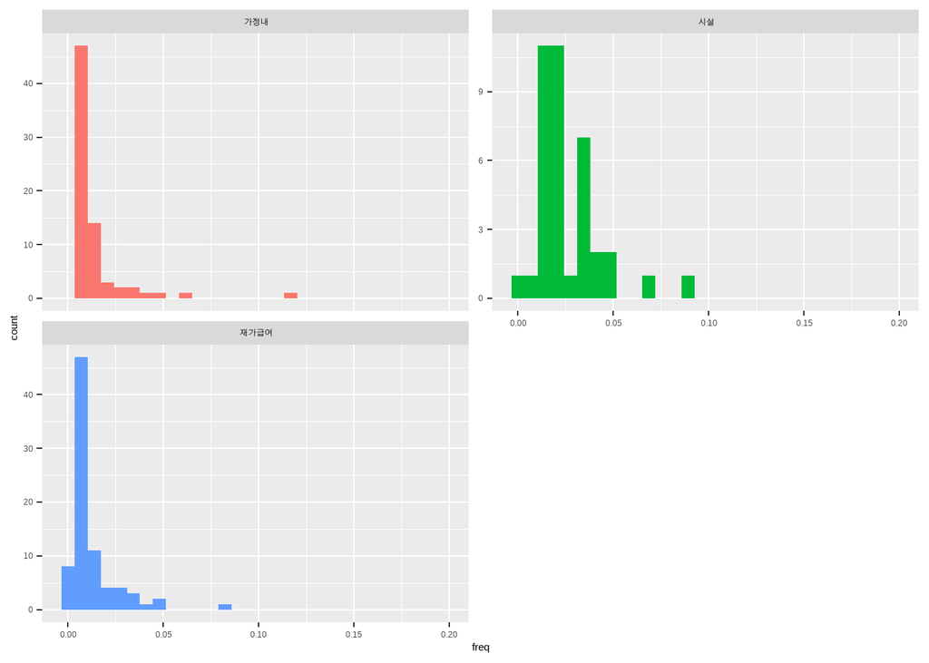

```r
library(ggplot2)

ggplot(frequency, aes(freq, fill = institute)) +
  geom_histogram(show.legend = FALSE) +
  xlim(NA, 0.20) +
  facet_wrap(~institute, ncol = 2, scales = "free_y")
```

```r
frequency1_tf_idf <- frequency %>%
  bind_tf_idf(nouns, institute, count)

frequency1_tf_idf
```

| institute | nouns | count | total | freq | tf | idf | tf_idf |
| --- | --- | --- | --- | --- | --- | --- | --- |
| 가정내 | 부분 | 193 | 1655 | 0.1166163142 | 0.1166163142 | 0.0000000 | 0.0000000000 |
| 가정내 | 아버님 | 108 | 1655 | 0.0652567976 | 0.0652567976 | 0.4054651 | 0.0264593545 |
| 가정내 | 목욕 | 83 | 1655 | 0.0501510574 | 0.0501510574 | 0.0000000 | 0.0000000000 |
| 가정내 | 때 | 64 | 1655 | 0.0386706949 | 0.0386706949 | 0.0000000 | 0.0000000000 |
| 가정내 | 음식 | 54 | 1655 | 0.0326283988 | 0.0326283988 | 1.0986123 | 0.0358459599 |
| 가정내 | 부담 | 52 | 1655 | 0.0314199396 | 0.0314199396 | 0.4054651 | 0.0127396892 |
| 가정내 | 허리 | 47 | 1655 | 0.0283987915 | 0.0283987915 | 0.0000000 | 0.0000000000 |
| 가정내 | 신체 | 41 | 1655 | 0.0247734139 | 0.0247734139 | 0.0000000 | 0.0000000000 |
| 가정내 | 거동 | 39 | 1655 | 0.0235649547 | 0.0235649547 | 1.0986123 | 0.0258887488 |
| 가정내 | 영역 | 34 | 1655 | 0.0205438066 | 0.0205438066 | 1.0986123 | 0.0225696784 |

[output cut: 181 more lines]

```r
frequency1_tf_idf <-frequency1_tf_idf %>%
  select(-total) %>%
  arrange(institute, desc(tf_idf))

write_xlsx(frequency1_tf_idf, "freq_tf_idf_phy_by_institute.xlsx")
```

- freq_tf_idf_phy_by_institute.xlsx ==> 시설별 신체적 부담 상위 td-idf 연관어

## 2.4. 시설별 TF-IDF 행렬 만들기

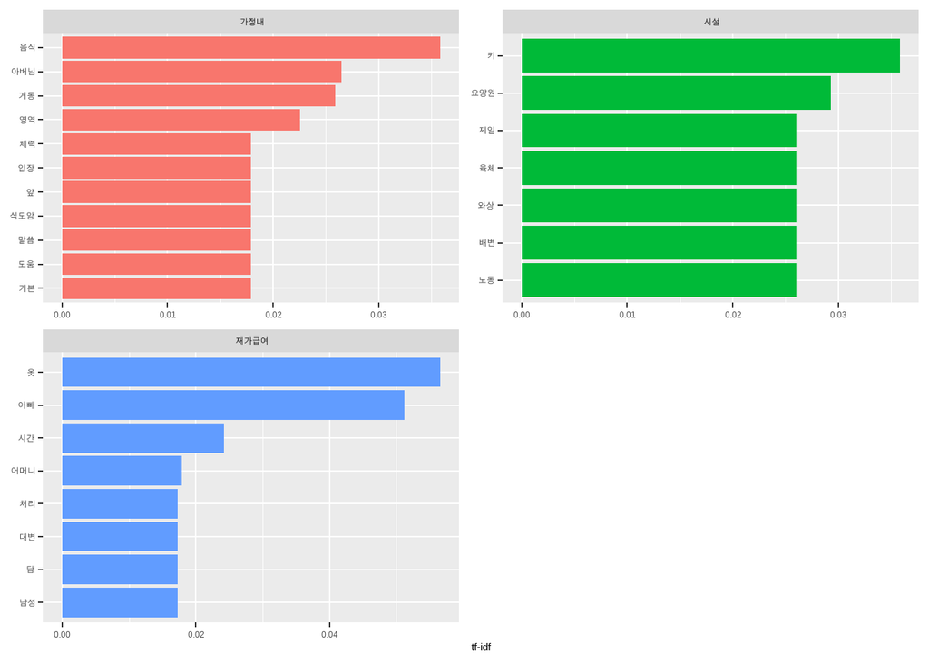

```r
library(forcats)

frequency1_tf_idf %>%
  group_by(institute) %>%
  slice_max(tf_idf, n = 7) %>%
  ungroup() %>%
  ggplot(aes(tf_idf, fct_reorder(nouns, tf_idf), fill = institute)) +
  geom_col(show.legend = FALSE) +
  facet_wrap(~institute, ncol = 2, scales = "free") +
  labs(x = "tf-idf", y = NULL)
```

```r
library(tidyr)
table(frequency$institute)
```

```
##
##   가정내     시설 재가급여
##       72       38       81
```

```r
frequency <- frequency %>%
  select(institute, nouns, freq) %>%
  pivot_wider(names_from = institute, values_from = freq)

frequency
```

| nouns | 가정내 | 시설 | 재가급여 |
| --- | --- | --- | --- |
| 부분 | 0.116616314 | 0.071111111 | 0.0367737190 |
| 아버님 | 0.065256798 | NA | 0.0039225300 |
| 목욕 | 0.050151057 | 0.023703704 | 0.0813924982 |
| 때 | 0.038670695 | 0.041481481 | 0.0073547438 |
| 음식 | 0.032628399 | NA | NA |
| 부담 | 0.031419940 | NA | 0.0291738171 |
| 허리 | 0.028398792 | 0.032592593 | 0.0012257906 |
| 신체 | 0.024773414 | 0.047407407 | 0.0205932827 |
| 거동 | 0.023564955 | NA | NA |
| 영역 | 0.020543807 | NA | NA |

[output cut: 134 more lines]

## 2.5. 시설별 단어빈도 비교

```r
word_ratios <- collapsed_dfphy2 %>%
  filter(count >= 10) %>%
  pivot_wider(names_from = institute, values_from = count, values_fill = 0) %>%
  mutate_if(is.numeric, list(~(. + 1) / (sum(.) + 1))) %>%
  mutate(logratio = log(시설/가정내)) %>%
  arrange(desc(logratio))
word_ratios %>%
  arrange(abs(logratio))
```

| nouns | 가정내 | 시설 | 재가급여 | logratio |
| --- | --- | --- | --- | --- |
| 때 | 0.0428194993 | 0.046474359 | 0.0076884921 | 0.08190715 |
| 허리 | 0.0316205534 | 0.036858974 | 0.0002480159 | 0.15329179 |
| 식사 | 0.0184453228 | 0.027243590 | 0.0002480159 | 0.39000742 |
| 부분 | 0.1277997365 | 0.078525641 | 0.0374503968 | -0.48703927 |
| 엄마 | 0.0164690382 | 0.027243590 | 0.0044642857 | 0.50333611 |
| 병원 | 0.0197628458 | 0.035256410 | 0.0076884921 | 0.57884366 |
| 신체 | 0.0276679842 | 0.052884615 | 0.0210813492 | 0.64783653 |
| 목욕 | 0.0553359684 | 0.027243590 | 0.0825892857 | -0.70860487 |
| 감당 | 0.0006587615 | 0.001602564 | 0.0044642857 | 0.88899859 |
| 감정 | 0.0006587615 | 0.001602564 | 0.0076884921 | 0.88899859 |

[output cut: 113 more lines]

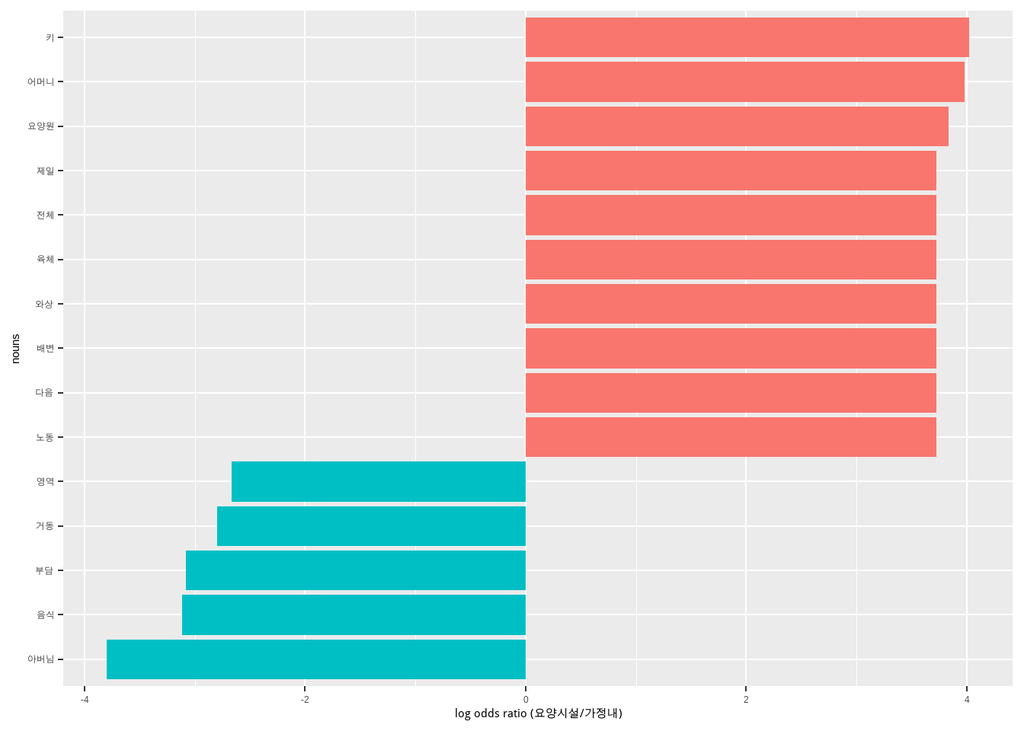

```r
word_ratios %>%
  group_by(logratio < 0) %>%
  slice_max(abs(logratio), n = 5) %>%
  ungroup() %>%
  mutate(nouns = reorder(nouns, logratio)) %>%
  ggplot(aes(nouns, logratio, fill = logratio < 0)) +
  geom_col(show.legend = FALSE) +
  coord_flip() +
  ylab("log odds ratio (요양시설/가정내)") +
  scale_fill_discrete(name = "", labels = c("요양시설", "가정내"))
```

### 2.5.2. 시설 대 재가급여

```r
word_ratios2 <- collapsed_dfphy2 %>%
  filter(count >= 10) %>%
  pivot_wider(names_from = institute, values_from = count, values_fill = 0) %>%
  mutate_if(is.numeric, list(~(. + 1) / (sum(.) + 1))) %>%
  mutate(logratio = log(시설/재가급여)) %>%
  arrange(desc(logratio))
word_ratios2 %>%
  arrange(abs(logratio))
```

| nouns | 가정내 | 시설 | 재가급여 | logratio |
| --- | --- | --- | --- | --- |
| 어머니 | 0.0006587615 | 0.035256410 | 0.0448908730 | -0.2415871 |
| 힘 | 0.0098814229 | 0.027243590 | 0.0349702381 | -0.2496791 |
| 다음 | 0.0006587615 | 0.027243590 | 0.0195932540 | 0.3296329 |
| 부분 | 0.1277997365 | 0.078525641 | 0.0374503968 | 0.7404079 |
| 신체 | 0.0276679842 | 0.052884615 | 0.0210813492 | 0.9197237 |
| 아버님 | 0.0718050066 | 0.001602564 | 0.0042162698 | -0.9673459 |
| 남자 | 0.0006587615 | 0.001602564 | 0.0042162698 | -0.9673459 |
| 여자 | 0.0006587615 | 0.001602564 | 0.0042162698 | -0.9673459 |
| 와중 | 0.0006587615 | 0.001602564 | 0.0042162698 | -0.9673459 |
| 감당 | 0.0006587615 | 0.001602564 | 0.0044642857 | -1.0245043 |

[output cut: 113 more lines]

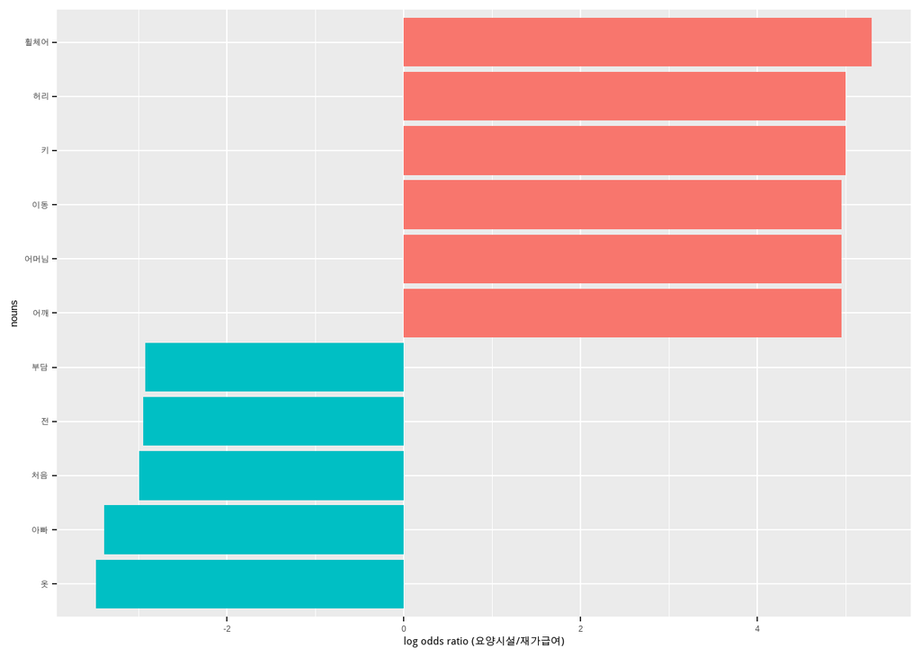

```r
word_ratios2 %>%
  group_by(logratio < 0) %>%
  slice_max(abs(logratio), n = 5) %>%
  ungroup() %>%
  mutate(nouns = reorder(nouns, logratio)) %>%
  ggplot(aes(nouns, logratio, fill = logratio < 0)) +
  geom_col(show.legend = FALSE) +
  coord_flip() +
  ylab("log odds ratio (요양시설/재가급여)") +
  scale_fill_discrete(name = "", labels = c("요양시설", "재가급여"))
```

```r
word_ratios3 <- collapsed_dfphy2 %>%
  filter(count >= 10) %>%
  pivot_wider(names_from = institute, values_from = count, values_fill = 0) %>%
  mutate_if(is.numeric, list(~(. + 1) / (sum(.) + 1))) %>%
  mutate(logratio = log(재가급여/시설)) %>%
  arrange(desc(logratio))
word_ratios3 %>%
  arrange(abs(logratio))
```

| nouns | 가정내 | 시설 | 재가급여 | logratio |
| --- | --- | --- | --- | --- |
| 어머니 | 0.0006587615 | 0.035256410 | 0.0448908730 | 0.2415871 |
| 힘 | 0.0098814229 | 0.027243590 | 0.0349702381 | 0.2496791 |
| 다음 | 0.0006587615 | 0.027243590 | 0.0195932540 | -0.3296329 |
| 부분 | 0.1277997365 | 0.078525641 | 0.0374503968 | -0.7404079 |
| 신체 | 0.0276679842 | 0.052884615 | 0.0210813492 | -0.9197237 |
| 아버님 | 0.0718050066 | 0.001602564 | 0.0042162698 | 0.9673459 |
| 남자 | 0.0006587615 | 0.001602564 | 0.0042162698 | 0.9673459 |
| 여자 | 0.0006587615 | 0.001602564 | 0.0042162698 | 0.9673459 |
| 와중 | 0.0006587615 | 0.001602564 | 0.0042162698 | 0.9673459 |
| 감당 | 0.0006587615 | 0.001602564 | 0.0044642857 | 1.0245043 |

[output cut: 113 more lines]

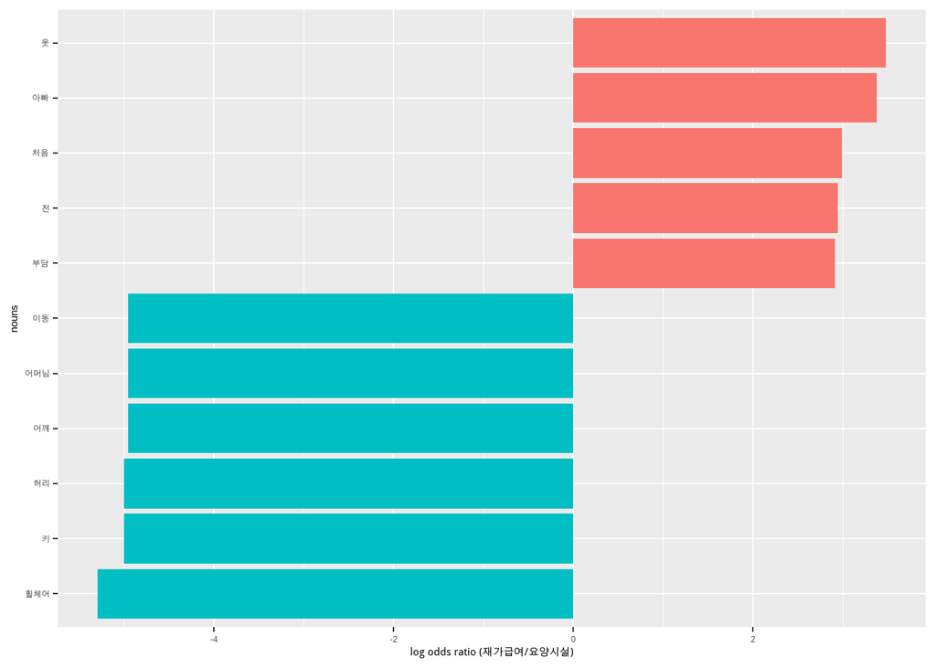

```r
word_ratios3 %>%
  group_by(logratio < 0) %>%
  slice_max(abs(logratio), n = 5) %>%
  ungroup() %>%
  mutate(nouns = reorder(nouns, logratio)) %>%
  ggplot(aes(nouns, logratio, fill = logratio < 0)) +
  geom_col(show.legend = FALSE) +
  coord_flip() +
  ylab("log odds ratio (재가급여/요양시설)") +
  scale_fill_discrete(name = "", labels = c("재가급여", "요양시설"))
```

## 2.6. 신체적부담 토픽모델링

### 2.6.1. 토픽모델링을 위한 데이터 변환

### LDA 기법

- Blei 등 일군의 전산학자들은 문서 내 단어의 확률분포를 계산해 찾아낸 일련의 단어 군집을 통해 문서의 주제를 추론하는 방법으로서 LDA(Latent Dirichlet Allocation)을 제시했다.
- 19세기 독일 수학자 러죈 디리클레(Lejeune Dirichlet, 1805 ~ 1859)가 제시한 디리클래 분포(Dirichlet distribution)를 이용해 문서에 잠재된 주제를 추론하기에 잠재 디리클레 할당(LDA: Latent Dirichlet Allocation)이라고 했다. 문서의 주제를 추론하는 방법이므로 주제모형(topic models)이라고 한다.

LDA에는 다음과 같은 전제가 있다.

LDA에서 정의하는 주제(topic)는 특정 단어에 대한 분포다. 예를 들어, 유전학 주제라면 유전학에 대하여 높은 확률로 분포하는 단어들이고, 진화생물학 주제라면 진화생물학에 대하여 높은 확률로 분포하는 단어들이다.

LDA에서는 문서를 주머니에 무작위로 섞여 있는 임의의 혼합물로 본다(Bag of words). 일반적으로 사용하는 문장처럼 문법이라는 짜임새있는 구조로 보는 것이 아니다. 임의의 혼합물이지만 온전하게 무작위로 섞여 있는 것은 아니다. 서로 함께 모여 있는 군집이 확률적으로 존재한다. 즉, 주제모형에서 접근하는 문서는 잠재된 주제의 혼합물로서, 각 주제를 구성하는 단어 단위가 확률적으로 혼합된 주머니(bag)인 셈이다.

- 개별 문서: 여러 주제(topic)가 섞여 있는 혼합물
- 문서마다 주제(예술, 교육, 예산 등)의 분포 비율 상이
- 주제(예: 예술)마다 단어(예: 오페라, 교향악단)의 분포 상이

주제모형의 목표는 말뭉치에서 주제의 자동추출이다. 문서 자체는 관측가능하지만, 주제의 구조(문서별 주제의 분포와 문서별-단어별 주제할당)는 감춰져 있다. 감춰진 주제의 구조를 찾아내는 작업은 뒤집어진 생성과정이라고 할 수 있다. 관측된 말뭉치를 생성하는 감춰진 구조를 찾아내는 작업이기 때문이다. 문서에 대한 사전 정보없이 문서의 주제를 분류하기 때문에 주제모형은 비지도학습(unsupervised learning) 방식의 기계학습(machine learning)이 된다.

- 기계학습(machine learing): 인공지능 작동방식. 투입한 데이터에서 규칙성 탐지해 분류 및 예측. 지도학습, 비지도학습, 강화학습 등으로 구분.
- 지도학습(supervised learning): 인간이 사전에 분류한 결과를 학습해 투입한 자료에서 규칙성 혹은 경향 발견
- 비지도학습(unsupervised learning): 사전분류한 결과 없이 기계 스스로 투입한 자료에서 규칙성 혹은 경향 발견
- 강화학습(reinforced learning): 행동의 결과에 대한 피드백(보상, 처벌 등)을 통해 투입한 자료에서 규칙성혹은 경향 발견

주제모형의 효용은 대량의 문서에서 의미구조를 닮은 주제구조를 추론해 주석을 자동으로 부여할 수 있다는데 있다.

주제모형은 다양한 패지키가 있다.

#### 적용 방법

실제로 거의 모든 주제 모델은 더 큰 k를 사용하지만 이 분석 접근 방식이 더 많은 수의 주제로 확장된다는 사실을 곧 알게 될 것입니다.

이 함수는 단어가 주제와 연결되는 방식, 주제가 문서와 연결되는 방식 등 모델 피팅의 전체 세부정보가 포함된 개체를 반환합니다.

```r
## DTM 변환
dfphy_dtm <- dfphy_bow %>%
  cast_dtm(document = no, term = nouns, value = n) %>%
  as.matrix
## LDA 모형 적합
dfphy_lda <- LDA(dfphy_dtm, k = 3,  method="Gibbs",
                  control=list(alpha=0.1, delta=0.1, seed=1357))
dfphy_topics <- tidy(dfphy_lda, matrix = "beta")
dfphy_topics
```

| topic | term | beta |
| --- | --- | --- |
| 1 | 어머니 | 0.0007552870 |
| 2 | 어머니 | 0.0593841642 |
| 3 | 어머니 | 0.0007974482 |
| 1 | 아빠 | 0.0007552870 |
| 2 | 아빠 | 0.0007331378 |
| 3 | 아빠 | 0.0486443381 |
| 1 | 옷 | 0.0007552870 |
| 2 | 옷 | 0.0153958944 |
| 3 | 옷 | 0.0486443381 |
| 1 | 부분 | 0.1442598187 |

[output cut: 422 more lines]

### 2.6.2. 세 개 주요토픽 추출

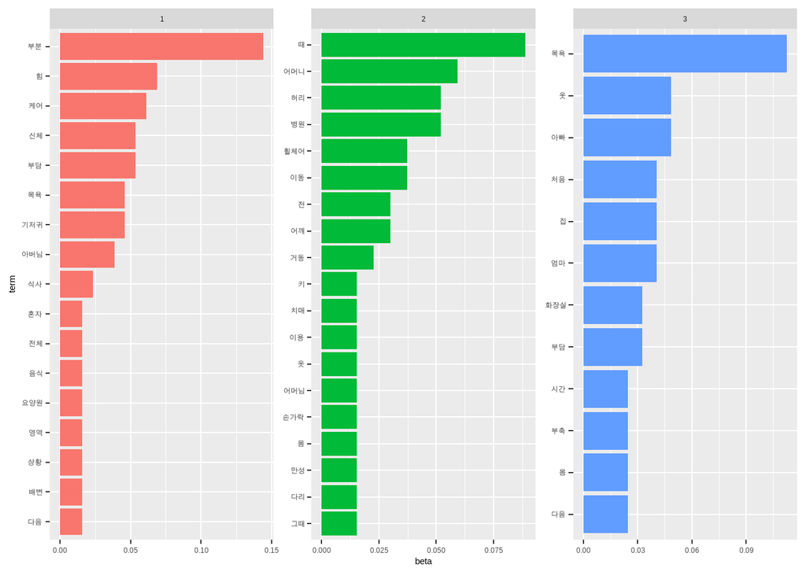

```r
dfphy_top_terms <- dfphy_topics %>%
  group_by(topic) %>%
  slice_max(beta, n = 10) %>%
  ungroup() %>%
  arrange(topic, -beta)

dfphy_top_terms %>%
  mutate(term = reorder_within(term, beta, topic)) %>%
  ggplot(aes(beta, term, fill = factor(topic))) +
  geom_col(show.legend = FALSE) +
  facet_wrap(~ topic, scales = "free") +
  scale_y_reordered()
```

* 주제 내에서 가장 일반적인 10개의 용어를 찾을 수 있습니다.그림으로 보여줍니다. * 이 부분은 정리해서 논문에 그림을 넣어주세요..

### 2.6.3. 토픽결과 행렬

```r
## 토픽 결과 - 행렬
tidy(dfphy_lda, matrix="gamma") %>%
  arrange(document) %>%
  spread(topic, gamma)
```

| document | 1 | 2 | 3 |
| --- | --- | --- | --- |
| 1 | 0.018867925 | 0.962264151 | 0.018867925 |
| 10 | 0.003095975 | 0.003095975 | 0.993808050 |
| 11 | 0.030303030 | 0.030303030 | 0.939393939 |
| 12 | 0.855421687 | 0.132530120 | 0.012048193 |
| 13 | 0.987730061 | 0.006134969 | 0.006134969 |
| 14 | 0.179190751 | 0.005780347 | 0.815028902 |
| 15 | 0.251028807 | 0.004115226 | 0.744855967 |
| 16 | 0.102310231 | 0.168316832 | 0.729372937 |
| 17 | 0.968253968 | 0.015873016 | 0.015873016 |
| 18 | 0.018867925 | 0.396226415 | 0.584905660 |

[output cut: 18 more lines]

### 2.6.4. 단어별 토픽 log-ratio

```r
library(tidyr)

beta_wide <- dfphy_topics %>%
  mutate(topic = paste0("topic", topic)) %>%
  pivot_wider(names_from = topic, values_from = beta) %>%
  filter(topic1 > .001 | topic2 > .001) %>%
  mutate(log_ratio = log2(topic2 / topic1))

beta_wide
```

| term | topic1 | topic2 | topic3 | log_ratio |
| --- | --- | --- | --- | --- |
| 어머니 | 0.000755287 | 0.0593841642 | 0.0007974482 | 6.29690948 |
| 옷 | 0.000755287 | 0.0153958944 | 0.0486443381 | 4.34937690 |
| 부분 | 0.144259819 | 0.0007331378 | 0.0007974482 | -7.62036935 |
| 목욕 | 0.046072508 | 0.0080645161 | 0.1124401914 | -2.51424624 |
| 아버님 | 0.038519637 | 0.0007331378 | 0.0007974482 | -5.71536586 |
| 케어 | 0.061178248 | 0.0007331378 | 0.0167464115 | -6.38279053 |
| 휠체어 | 0.000755287 | 0.0373900293 | 0.0007974482 | 5.62948482 |
| 병원 | 0.000755287 | 0.0520527859 | 0.0007974482 | 6.10680660 |
| 전 | 0.000755287 | 0.0300586510 | 0.0087719298 | 5.31461148 |
| 힘 | 0.068731118 | 0.0007331378 | 0.0007974482 | -6.55073516 |

[output cut: 98 more lines]

## 2.7. 신체적 부담 토픽 결과 - 시각화

### 2.7.1. 시설별 토픽 분류

```r
dfphy_gamma <- tidy(dfphy_lda, matrix="gamma")
dfphy_gamma$no=as.numeric(dfphy_gamma$document)
dfphy_gamma <- left_join(dfphy_gamma, dfphy_tk)
```

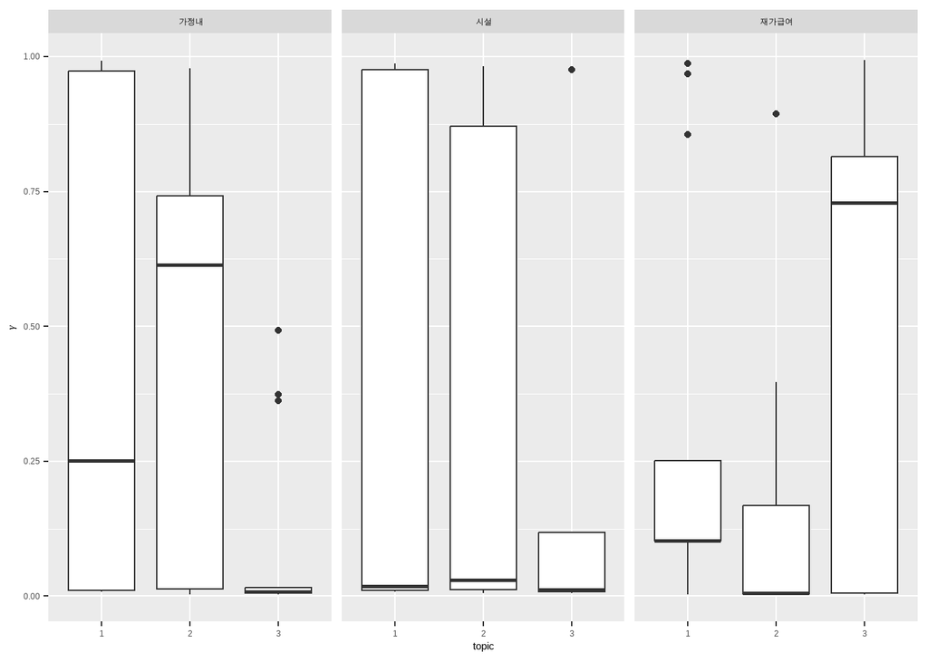

```r
dfphy_gamma %>%
  ggplot(aes(factor(topic), gamma)) +
  geom_boxplot() +
  facet_wrap(~ institute) +
  labs(x = "topic", y = expression(gamma))
```

### 2.7.2. 주관적 신체적 부담 수준별 (상중하) 토픽 분류

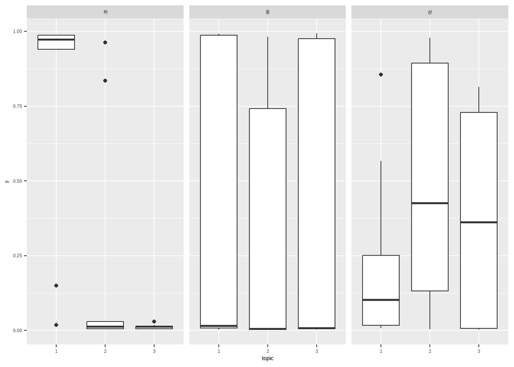

```r
dfphy_gamma$physical= as.factor(dfphy_gamma$physical)
dfphy_gamma %>%
  mutate(physical = reorder(physical, gamma * topic)) %>%
  ggplot(aes(factor(topic), gamma)) +
  geom_boxplot() +
  facet_wrap(~ physical) +
  labs(x = "topic", y = expression(gamma))
```

### 2.7.3. 세개의 토픽에 주로 연결되는 보호자

```r
tidy(dfphy_lda, matrix="gamma") %>%
  filter((topic==1 & gamma > .9) | (topic==2 & gamma > .9) |(topic==3 & gamma > .9))
```

| document | topic | gamma |
| --- | --- | --- |
| 19 | 1 | 0.9926740 |
| 2 | 1 | 0.9877301 |
| 13 | 1 | 0.9877301 |
| 5 | 1 | 0.9759036 |
| 17 | 1 | 0.9682540 |
| 20 | 1 | 0.9726027 |
| 3 | 1 | 0.9393939 |
| 1 | 2 | 0.9622642 |
| 7 | 2 | 0.9823009 |
| 24 | 2 | 0.9784946 |

[output cut: 5 more lines]

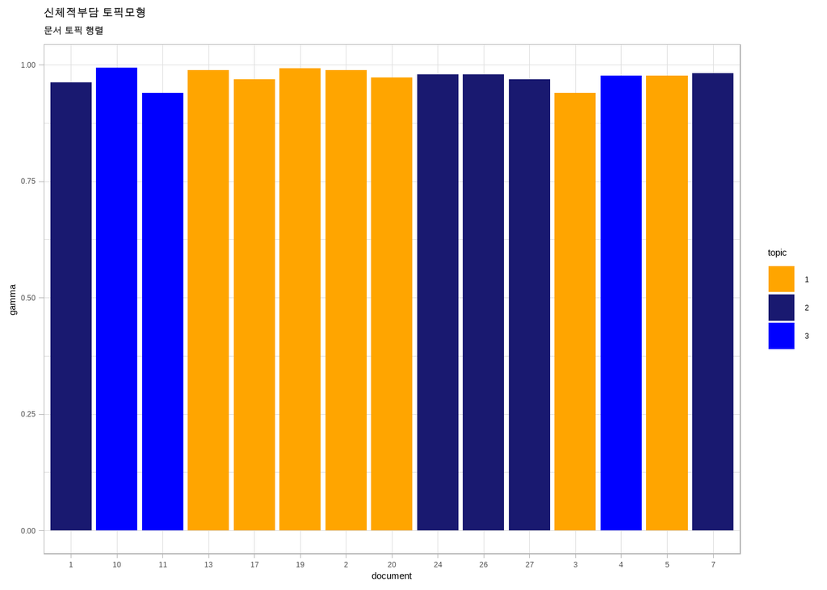

```r
dfphy_topic_g <- tidy(dfphy_lda, matrix="gamma") %>%
  filter((topic==1 & gamma > .9) | (topic==2 & gamma > .9) |(topic==3 & gamma > .9)) %>%
  mutate(topic = as.factor(topic)) %>%
  ggplot(aes(x = document, y=gamma)) +
    geom_col(aes(fill = topic), position=position_dodge()) +
    scale_fill_manual(values = c("orange", "midnightblue", "blue")) +
    theme_light() +
    labs(title="신체적부담 토픽모형",
         subtitle = "문서 토픽 행렬")
dfphy_topic_g
```

# 3. 경제적 부담 토픽분석

## 3.1. 경제적 부담 텍스트 전처리

```r
rm(list=ls())
df <- readxl::read_excel("df5.xlsx")
df<-unite(df, col='eco1', c('eco1', 'eco2'), sep='. ')
df_eco<-df%>%
  select(no, eco1, institute, economic)
```

```r
dfeco_tk <- df_eco %>%
  # 문자 혹은 공백 이외 것 제거
  mutate(text = str_remove_all(eco1, "[^(\\w+|\\s)]")) %>%
  # 메카브로 품사 중 명사만 추출
  unnest_tokens(word, text, token = RcppMeCab::pos, drop = FALSE) %>%
  separate(col = word,
         into = c("word", "morph"),
         sep = "/" ) %>%
  filter(morph == "nng")

dfeco_tk %>% glimpse()
```

```
## Rows: 241
## Columns: 7
## $ no        <dbl> 1, 1, 1, 1, 1, 1, 1, 1, 2, 2, 2, 2, 2, 2, 2, 2, 2, 2, 2, 2, …
## $ eco1      <chr> "갑작스럽게 다쳤을 때 병원에 입원하면은 간병비가 좀 부담스러…
## $ institute <chr> "시설", "시설", "시설", "시설", "시설", "시설", "시설", "시…
## $ economic  <chr> "상", "상", "상", "상", "상", "상", "상", "상", "중", "중", …
## $ text      <chr> "갑작스럽게 다쳤을 때 병원에 입원하면은 간병비가 좀 부담스러…
## $ word      <chr> "때", "병원", "입원", "병비", "부담", "가정", "경제", "부담"…
## $ morph     <chr> "nng", "nng", "nng", "nng", "nng", "nng", "nng", "nng", "nng…
```

```r
dfeco_tk$no <- as.numeric(dfeco_tk$no)
```

## 3.2. 데이터 변환

```r
## BOW 데이터 변환
dfeco_bow <- df_eco %>%
  ## 문서 내 텍스트에서 명사 추출
  mutate(mecab_pos = map(eco1, RcppMeCab::pos) ) %>%
  unnest(mecab_pos) %>%
  unnest(mecab_pos) %>%
  separate(mecab_pos, into = c("nouns", "pos"), sep = "/") %>%
  filter(pos == "NNG") %>%
  ## 문서별 명사 빈도수
  group_by(no) %>%
  count(nouns, sort = TRUE)
dfeco_bow$no <- as.numeric(dfeco_bow$no)

dfeco2 <- inner_join(dfeco_bow, dfeco_tk)
collapsed_dfeco2 <- dfeco2 %>%
  group_by(nouns) %>%
  summarize(count = sum(n, na.rm = TRUE))

collapsed_dfeco2$total <- sum(collapsed_dfeco2$count)
collapsed_dfeco2$freq <- collapsed_dfeco2$count/collapsed_dfeco2$total
freq_eco_all<-collapsed_dfeco2  %>%
  filter(count>29)

freq_eco_all <- freq_eco_all[order(-freq_eco_all$count), ]

write_xlsx(freq_eco_all, "freq_eco_all.xlsx")


collapsed_dfeco2 <- dfeco2 %>%
  group_by(institute, nouns) %>%
  summarize(count = sum(n, na.rm = TRUE))
```

- freq_eco_all.xlsx ==> <경제적 부담의 상위 연관어>

```r
png("eco_plot.png")
eco_plot<- ggplot(data = freq_eco_all, aes(label = nouns, size = count, color = count))+
  geom_text_wordcloud_area(area_corr_power = 1, eccentricity = 1)+
  scale_size_area(max_size = 20) +
  scale_color_gradient(low = "#C7DDEC", high = "#1F78B4") +
  theme_minimal()
print(eco_plot)
dev.off()
```

## 3.3. 시설별 단어 빈도분석

```r
frequency <- collapsed_dfeco2 %>%
  left_join(collapsed_dfeco2 %>% group_by(institute)%>%
              summarize(total=sum(count, na.rm=TRUE))) %>%
  mutate(freq = count/total)
frequency<- frequency[order(frequency$institute, -frequency$freq), ]
frequency
```

| institute | nouns | count | total | freq |
| --- | --- | --- | --- | --- |
| 가정내 | 경비 | 40 | 806 | 0.0496277916 |
| 가정내 | 식사 | 38 | 806 | 0.0471464020 |
| 가정내 | 아버님 | 38 | 806 | 0.0471464020 |
| 가정내 | 준비 | 38 | 806 | 0.0471464020 |
| 가정내 | 지출 | 31 | 806 | 0.0384615385 |
| 가정내 | 때 | 25 | 806 | 0.0310173697 |
| 가정내 | 앞 | 22 | 806 | 0.0272952854 |
| 가정내 | 과일 | 19 | 806 | 0.0235732010 |
| 가정내 | 다달 | 19 | 806 | 0.0235732010 |
| 가정내 | 돈 | 19 | 806 | 0.0235732010 |

[output cut: 151 more lines]

```r
write_xlsx(freq_eco_all, "freq_eco_by_institute.xlsx")
```

```r
summary(frequency)
```

```
##   institute            nouns               count            total
##  Length:161         Length:161         Min.   :  2.00   Min.   : 747
##  Class :character   Class :character   1st Qu.: 11.00   1st Qu.: 747
##  Mode  :character   Mode  :character   Median : 14.00   Median : 806
##                                        Mean   : 32.86   Mean   :1883
##                                        3rd Qu.: 38.00   3rd Qu.:3738
##                                        Max.   :522.00   Max.   :3738
##       freq
##  Min.   :0.0008026
##  1st Qu.:0.0074442
##  Median :0.0155163
##  Mean   :0.0186335
##  3rd Qu.:0.0235732
##  Max.   :0.1396469
```

```r
summary(frequency$count)
```

```
##    Min. 1st Qu.  Median    Mean 3rd Qu.    Max.
##    2.00   11.00   14.00   32.86   38.00  522.00
```

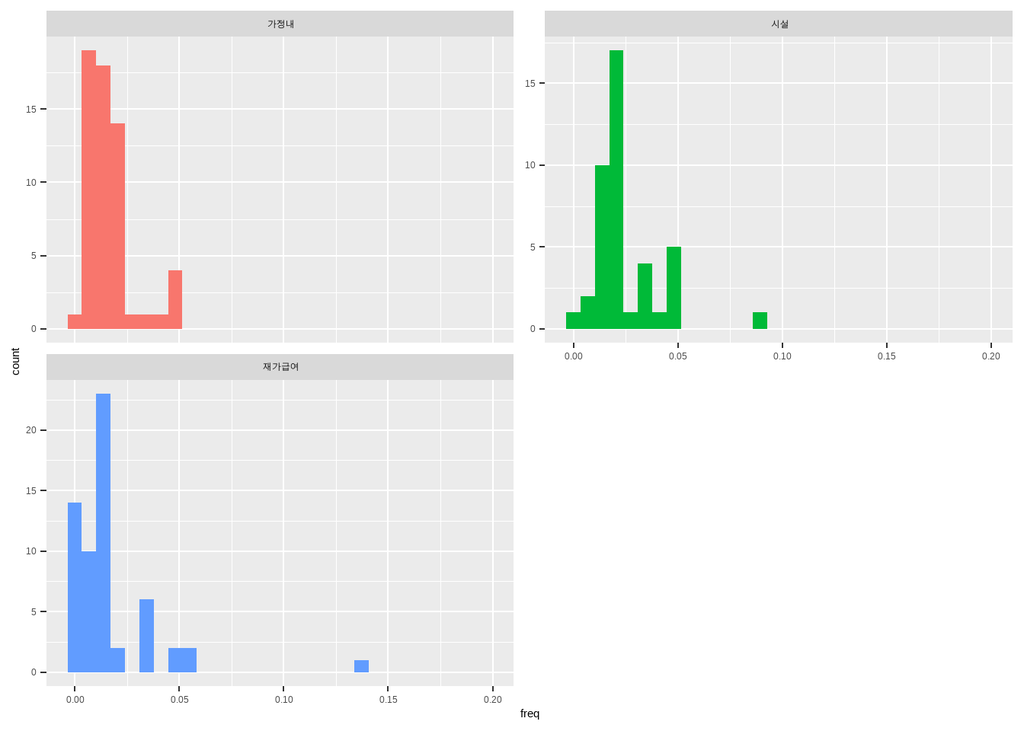

```r
library(ggplot2)

ggplot(frequency, aes(freq, fill = institute)) +
  geom_histogram(show.legend = FALSE) +
  xlim(NA, 0.20) +
  facet_wrap(~institute, ncol = 2, scales = "free_y")
```

```r
frequency1_tf_idf <- frequency %>%
  bind_tf_idf(nouns, institute, count)

frequency1_tf_idf
```

| institute | nouns | count | total | freq | tf | idf | tf_idf |
| --- | --- | --- | --- | --- | --- | --- | --- |
| 가정내 | 경비 | 40 | 806 | 0.0496277916 | 0.0496277916 | 0.4054651 | 0.0201223379 |
| 가정내 | 식사 | 38 | 806 | 0.0471464020 | 0.0471464020 | 1.0986123 | 0.0517956166 |
| 가정내 | 아버님 | 38 | 806 | 0.0471464020 | 0.0471464020 | 1.0986123 | 0.0517956166 |
| 가정내 | 준비 | 38 | 806 | 0.0471464020 | 0.0471464020 | 0.4054651 | 0.0191162210 |
| 가정내 | 지출 | 31 | 806 | 0.0384615385 | 0.0384615385 | 0.0000000 | 0.0000000000 |
| 가정내 | 때 | 25 | 806 | 0.0310173697 | 0.0310173697 | 0.0000000 | 0.0000000000 |
| 가정내 | 앞 | 22 | 806 | 0.0272952854 | 0.0272952854 | 0.4054651 | 0.0110672858 |
| 가정내 | 과일 | 19 | 806 | 0.0235732010 | 0.0235732010 | 1.0986123 | 0.0258978083 |
| 가정내 | 다달 | 19 | 806 | 0.0235732010 | 0.0235732010 | 1.0986123 | 0.0258978083 |
| 가정내 | 돈 | 19 | 806 | 0.0235732010 | 0.0235732010 | 0.4054651 | 0.0095581105 |

[output cut: 151 more lines]

```r
frequency1_tf_idf <-frequency1_tf_idf %>%
  select(-total) %>%
  arrange(institute, desc(tf_idf))

write_xlsx(frequency1_tf_idf, "freq_tf_idf_eco_by_institute.xlsx")
```

- freq_tf_idf_eco_by_institute.xlsx ==> 시설별 경제적 부담 상위 td-idf 연관어

## 3.4. 시설별 TF-IDF 행렬 만들기

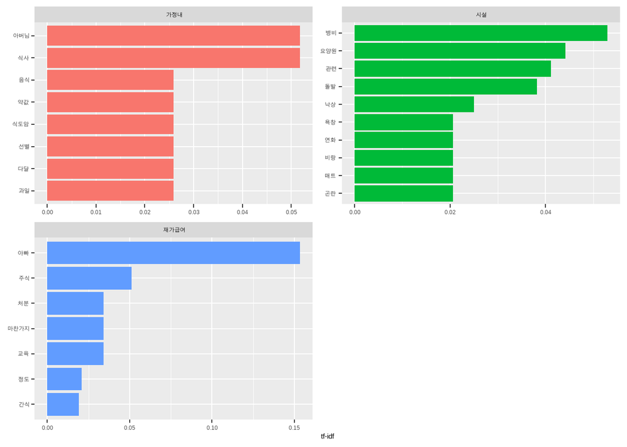

```r
library(forcats)

frequency1_tf_idf %>%
  group_by(institute) %>%
  slice_max(tf_idf, n = 7) %>%
  ungroup() %>%
  ggplot(aes(tf_idf, fct_reorder(nouns, tf_idf), fill = institute)) +
  geom_col(show.legend = FALSE) +
  facet_wrap(~institute, ncol = 2, scales = "free") +
  labs(x = "tf-idf", y = NULL)
```

```r
library(tidyr)
table(frequency$institute)
```

```
##
##   가정내     시설 재가급여
##       59       42       60
```

```r
frequency <- frequency %>%
  select(institute, nouns, freq) %>%
  pivot_wider(names_from = institute, values_from = freq)

frequency
```

| nouns | 가정내 | 시설 | 재가급여 |
| --- | --- | --- | --- |
| 경비 | 0.049627792 | 0.037483266 | NA |
| 식사 | 0.047146402 | NA | NA |
| 아버님 | 0.047146402 | NA | NA |
| 준비 | 0.047146402 | 0.014725569 | NA |
| 지출 | 0.038461538 | 0.017402945 | 0.0085607277 |
| 때 | 0.031017370 | 0.045515395 | 0.0508293205 |
| 앞 | 0.027295285 | NA | 0.0018726592 |
| 과일 | 0.023573201 | NA | NA |
| 다달 | 0.023573201 | NA | NA |
| 돈 | 0.023573201 | NA | 0.0061530230 |

[output cut: 114 more lines]

## 3.5. 시설별 단어빈도 비교

### 3.5.1. 시설 대 가정내

```r
word_ratios <- collapsed_dfeco2 %>%
  filter(count >= 10) %>%
  pivot_wider(names_from = institute, values_from = count, values_fill = 0) %>%
  mutate_if(is.numeric, list(~(. + 1) / (sum(.) + 1))) %>%
  mutate(logratio = log(시설/가정내)) %>%
  arrange(desc(logratio))
word_ratios %>%
  arrange(abs(logratio))
```

| nouns | 가정내 | 시설 | 재가급여 | logratio |
| --- | --- | --- | --- | --- |
| 가정 | 0.00143472 | 0.00140056 | 0.0046245919 | -0.02409755 |
| 가족 | 0.00143472 | 0.00140056 | 0.0160500544 | -0.02409755 |
| 간식 | 0.00143472 | 0.00140056 | 0.0179542982 | -0.02409755 |
| 감사 | 0.00143472 | 0.00140056 | 0.0160500544 | -0.02409755 |
| 건강 | 0.00143472 | 0.00140056 | 0.0160500544 | -0.02409755 |
| 경우 | 0.00143472 | 0.00140056 | 0.0160500544 | -0.02409755 |
| 교육 | 0.00143472 | 0.00140056 | 0.0318280740 | -0.02409755 |
| 기억 | 0.00143472 | 0.00140056 | 0.0160500544 | -0.02409755 |
| 기타 | 0.00143472 | 0.00140056 | 0.0046245919 | -0.02409755 |
| 끝 | 0.00143472 | 0.00140056 | 0.0160500544 | -0.02409755 |

[output cut: 86 more lines]

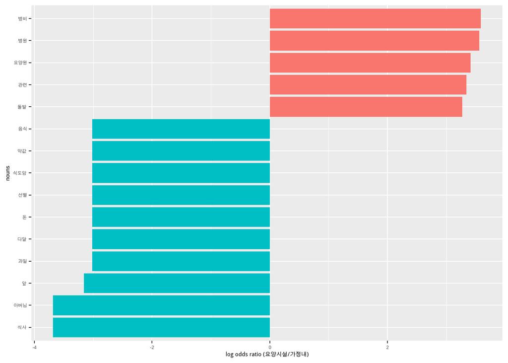

```r
word_ratios %>%
  group_by(logratio < 0) %>%
  slice_max(abs(logratio), n = 5) %>%
  ungroup() %>%
  mutate(nouns = reorder(nouns, logratio)) %>%
  ggplot(aes(nouns, logratio, fill = logratio < 0)) +
  geom_col(show.legend = FALSE) +
  coord_flip() +
  ylab("log odds ratio (요양시설/가정내)") +
  scale_fill_discrete(name = "", labels = c("요양시설", "가정내"))
```

### 3.5.2. 시설 대 재가급여

```r
word_ratios2 <- collapsed_dfeco2 %>%
  filter(count >= 10) %>%
  pivot_wider(names_from = institute, values_from = count, values_fill = 0) %>%
  mutate_if(is.numeric, list(~(. + 1) / (sum(.) + 1))) %>%
  mutate(logratio = log(시설/재가급여)) %>%
  arrange(desc(logratio))
word_ratios2 %>%
  arrange(abs(logratio))
```

| nouns | 가정내 | 시설 | 재가급여 | logratio |
| --- | --- | --- | --- | --- |
| 때 | 0.03730273 | 0.04901961 | 0.0519586507 | -0.05822785 |
| 스트레스 | 0.02439024 | 0.02100840 | 0.0171381937 | 0.20361300 |
| 케어 | 0.00143472 | 0.02100840 | 0.0160500544 | 0.26921028 |
| 정도 | 0.00143472 | 0.03501401 | 0.0527747552 | -0.41028481 |
| 부담 | 0.01578192 | 0.09523810 | 0.0538628945 | 0.56993820 |
| 비용 | 0.00143472 | 0.01960784 | 0.0361806311 | -0.61259428 |
| 자녀 | 0.00143472 | 0.01680672 | 0.0318280740 | -0.63856976 |
| 지출 | 0.04591105 | 0.01960784 | 0.0089771491 | 0.78124729 |
| 경제 | 0.02295552 | 0.00140056 | 0.0046245919 | -1.19451582 |
| 가정 | 0.00143472 | 0.00140056 | 0.0046245919 | -1.19451582 |

[output cut: 86 more lines]

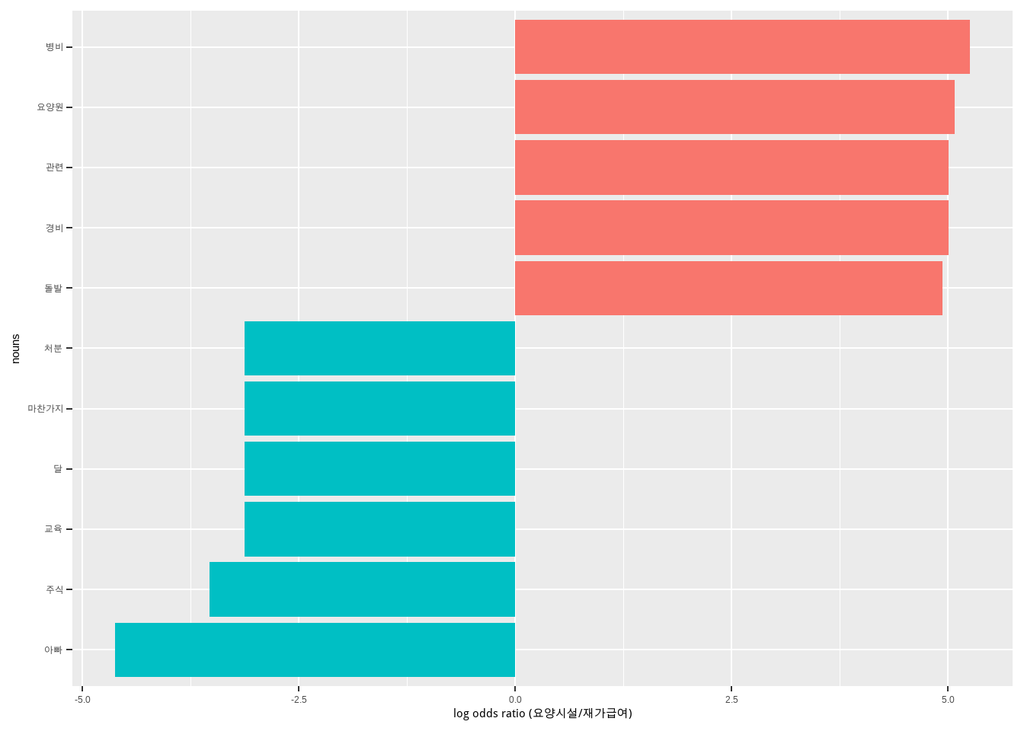

```r
word_ratios2 %>%
  group_by(logratio < 0) %>%
  slice_max(abs(logratio), n = 5) %>%
  ungroup() %>%
  mutate(nouns = reorder(nouns, logratio)) %>%
  ggplot(aes(nouns, logratio, fill = logratio < 0)) +
  geom_col(show.legend = FALSE) +
  coord_flip() +
  ylab("log odds ratio (요양시설/재가급여)") +
  scale_fill_discrete(name = "", labels = c("요양시설", "재가급여"))
```

```r
word_ratios3 <- collapsed_dfeco2 %>%
  filter(count >= 10) %>%
  pivot_wider(names_from = institute, values_from = count, values_fill = 0) %>%
  mutate_if(is.numeric, list(~(. + 1) / (sum(.) + 1))) %>%
  mutate(logratio = log(재가급여/시설)) %>%
  arrange(desc(logratio))
word_ratios3 %>%
  arrange(abs(logratio))
```

| nouns | 가정내 | 시설 | 재가급여 | logratio |
| --- | --- | --- | --- | --- |
| 때 | 0.03730273 | 0.04901961 | 0.0519586507 | 0.05822785 |
| 스트레스 | 0.02439024 | 0.02100840 | 0.0171381937 | -0.20361300 |
| 케어 | 0.00143472 | 0.02100840 | 0.0160500544 | -0.26921028 |
| 정도 | 0.00143472 | 0.03501401 | 0.0527747552 | 0.41028481 |
| 부담 | 0.01578192 | 0.09523810 | 0.0538628945 | -0.56993820 |
| 비용 | 0.00143472 | 0.01960784 | 0.0361806311 | 0.61259428 |
| 자녀 | 0.00143472 | 0.01680672 | 0.0318280740 | 0.63856976 |
| 지출 | 0.04591105 | 0.01960784 | 0.0089771491 | -0.78124729 |
| 경제 | 0.02295552 | 0.00140056 | 0.0046245919 | 1.19451582 |
| 가정 | 0.00143472 | 0.00140056 | 0.0046245919 | 1.19451582 |

[output cut: 86 more lines]

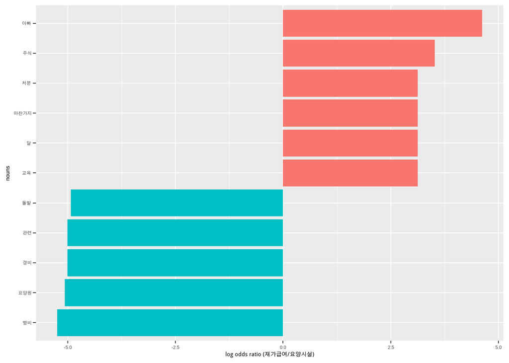

```r
word_ratios3 %>%
  group_by(logratio < 0) %>%
  slice_max(abs(logratio), n = 5) %>%
  ungroup() %>%
  mutate(nouns = reorder(nouns, logratio)) %>%
  ggplot(aes(nouns, logratio, fill = logratio < 0)) +
  geom_col(show.legend = FALSE) +
  coord_flip() +
  ylab("log odds ratio (재가급여/요양시설)") +
  scale_fill_discrete(name = "", labels = c("재가급여", "요양시설"))
```

## 3.6. 경제적 부담 토픽모델링

### 3.6.1. 토픽모델링을 위한 데이터 변환

```r
## DTM 변환
dfeco_dtm <- dfeco_bow %>%
  cast_dtm(document = no, term = nouns, value = n) %>%
  as.matrix
## LDA 모형 적합
dfeco_lda <- LDA(dfeco_dtm, k = 3,  method="Gibbs",
                  control=list(alpha=0.1, delta=0.1, seed=1357))
dfeco_topics <- tidy(dfeco_lda, matrix = "beta")
dfeco_topics
```

| topic | term | beta |
| --- | --- | --- |
| 1 | 아빠 | 0.0008305648 |
| 2 | 아빠 | 0.1017897092 |
| 3 | 아빠 | 0.0014409222 |
| 1 | 때 | 0.0672757475 |
| 2 | 때 | 0.0123042506 |
| 3 | 때 | 0.0014409222 |
| 1 | 부담 | 0.0755813953 |
| 2 | 부담 | 0.0458612975 |
| 3 | 부담 | 0.0014409222 |
| 1 | 정도 | 0.0008305648 |

[output cut: 362 more lines]

### 3.6.2. 세 개 주요토픽 추출

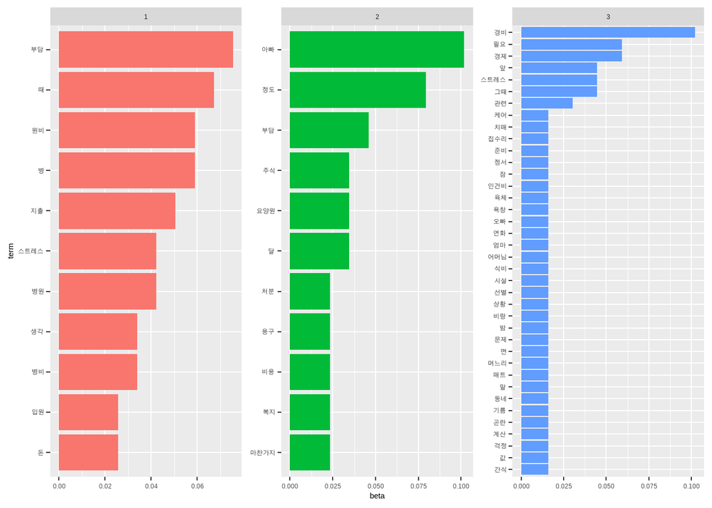

```r
dfeco_top_terms <- dfeco_topics %>%
  group_by(topic) %>%
  slice_max(beta, n = 10) %>%
  ungroup() %>%
  arrange(topic, -beta)

dfeco_top_terms %>%
  mutate(term = reorder_within(term, beta, topic)) %>%
  ggplot(aes(beta, term, fill = factor(topic))) +
  geom_col(show.legend = FALSE) +
  facet_wrap(~ topic, scales = "free") +
  scale_y_reordered()
```

### 3.6.3. 토픽결과 행렬

```r
## 토픽 결과 - 행렬
tidy(dfeco_lda, matrix="gamma") %>%
  arrange(document) %>%
  spread(topic, gamma)
```

| document | 1 | 2 | 3 |
| --- | --- | --- | --- |
| 1 | 0.870967742 | 0.010752688 | 0.118279570 |
| 10 | 0.156089194 | 0.842195540 | 0.001715266 |
| 11 | 0.023255814 | 0.023255814 | 0.953488372 |
| 12 | 0.561643836 | 0.013698630 | 0.424657534 |
| 13 | 0.742331288 | 0.190184049 | 0.067484663 |
| 14 | 0.962264151 | 0.018867925 | 0.018867925 |
| 15 | 0.030303030 | 0.939393939 | 0.030303030 |
| 17 | 0.939393939 | 0.030303030 | 0.030303030 |
| 18 | 0.939393939 | 0.030303030 | 0.030303030 |
| 19 | 0.937823834 | 0.005181347 | 0.056994819 |

[output cut: 16 more lines]

### 3.6.4. 단어별 토픽 log-ratio

```r
library(tidyr)

beta_wide <- dfeco_topics %>%
  mutate(topic = paste0("topic", topic)) %>%
  pivot_wider(names_from = topic, values_from = beta) %>%
  filter(topic1 > .001 | topic2 > .001) %>%
  mutate(log_ratio = log2(topic2 / topic1))

beta_wide
```

| term | topic1 | topic2 | topic3 | log_ratio |
| --- | --- | --- | --- | --- |
| 아빠 | 0.0008305648 | 0.101789709 | 0.001440922 | 6.9372833 |
| 때 | 0.0672757475 | 0.012304251 | 0.001440922 | -2.4509297 |
| 부담 | 0.0755813953 | 0.045861298 | 0.001440922 | -0.7207540 |
| 정도 | 0.0008305648 | 0.079418345 | 0.001440922 | 6.5792358 |
| 주식 | 0.0008305648 | 0.034675615 | 0.001440922 | 5.3836850 |
| 경비 | 0.0008305648 | 0.001118568 | 0.102305476 | 0.4294887 |
| 관련 | 0.0008305648 | 0.001118568 | 0.030259366 | 0.4294887 |
| 요양원 | 0.0008305648 | 0.034675615 | 0.001440922 | 5.3836850 |
| 돌발 | 0.0174418605 | 0.001118568 | 0.001440922 | -3.9628288 |
| 교육 | 0.0174418605 | 0.001118568 | 0.001440922 | -3.9628288 |

[output cut: 114 more lines]

## 3.7. 경제적 부담 토픽 결과 - 시각화

### 3.7.1. 시설별 토픽 분류

```r
dfeco_gamma <- tidy(dfeco_lda, matrix="gamma")
dfeco_gamma$no=as.numeric(dfeco_gamma$document)
dfeco_gamma <- left_join(dfeco_gamma, dfeco_tk)
```

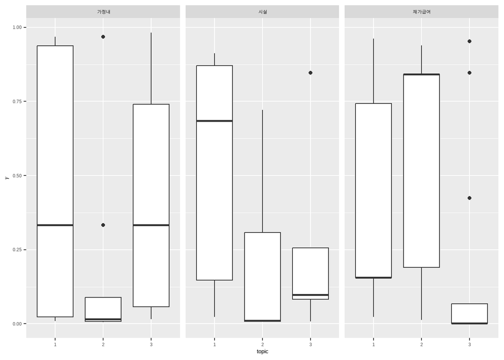

```r
dfeco_gamma %>%
  ggplot(aes(factor(topic), gamma)) +
  geom_boxplot() +
  facet_wrap(~ institute) +
  labs(x = "topic", y = expression(gamma))
```

### 3.7.2. 주관적 경제적 부담 수준별 (상중하) 토픽 분류

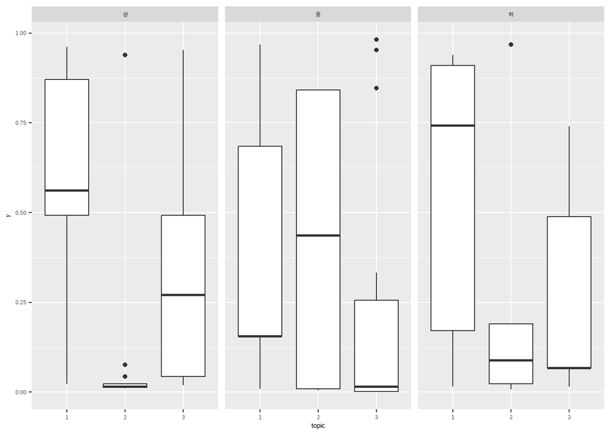

```r
dfeco_gamma$economic= as.factor(dfeco_gamma$economic)
dfeco_gamma %>%
  mutate(eoconomic = reorder(economic, gamma * topic)) %>%
  ggplot(aes(factor(topic), gamma)) +
  geom_boxplot() +
  facet_wrap(~ economic) +
  labs(x = "topic", y = expression(gamma))
```

### 3.7.3. 세개의 토픽에 주로 연결되는 보호자

```r
tidy(dfeco_lda, matrix="gamma") %>%
  filter((topic==1 & gamma > .8) | (topic==2 & gamma > .7) |(topic==3 & gamma > .9))
```

| document | topic | gamma |
| --- | --- | --- |
| 1 | 1 | 0.8709677 |
| 5 | 1 | 0.9097744 |
| 19 | 1 | 0.9378238 |
| 8 | 1 | 0.9130435 |
| 14 | 1 | 0.9622642 |
| 17 | 1 | 0.9393939 |
| 18 | 1 | 0.9393939 |
| 23 | 1 | 0.9682540 |
| 25 | 1 | 0.9130435 |
| 10 | 2 | 0.8421955 |

[output cut: 6 more lines]

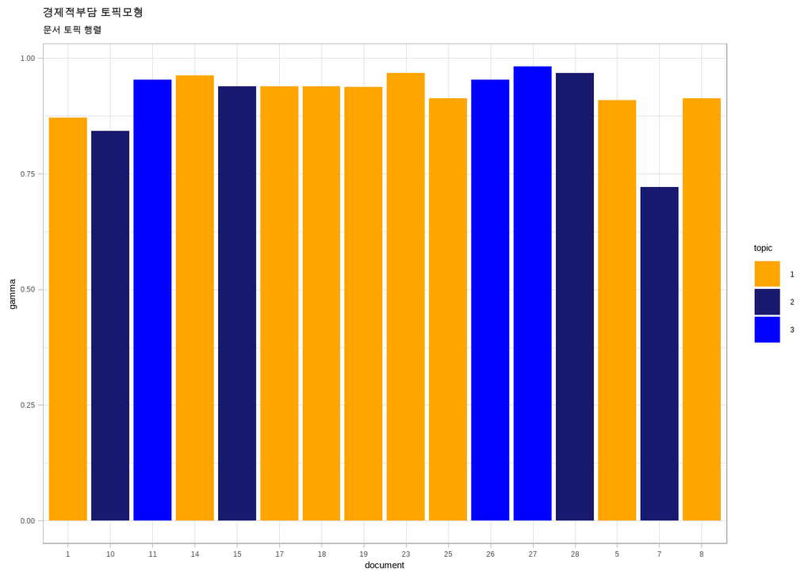

```r
dfeco_topic_g <- tidy(dfeco_lda, matrix="gamma") %>%
  filter((topic==1 & gamma > .8) | (topic==2 & gamma > .7) |(topic==3 & gamma > .9)) %>%
  mutate(topic = as.factor(topic)) %>%
  ggplot(aes(x = document, y=gamma)) +
    geom_col(aes(fill = topic), position=position_dodge()) +
    scale_fill_manual(values = c("orange", "midnightblue", "blue")) +
    theme_light() +
    labs(title="경제적부담 토픽모형",
         subtitle = "문서 토픽 행렬")
dfeco_topic_g
```

# 4. 사회적 부담 토픽분석

## 4.1. 사회적 부담 텍스트 전처리

```r
rm(list=ls())
df <- readxl::read_excel("df5.xlsx")
df<-unite(df, col='soc1', c('soc1', 'soc2'), sep='. ')
df_soc<-df%>%
  select(no, soc1, institute, social)
```

```r
dfsoc_tk <- df_soc %>%
  # 문자 혹은 공백 이외 것 제거
  mutate(text = str_remove_all(soc1, "[^(\\w+|\\s)]")) %>%
  # 메카브로 품사 중 명사만 추출
  unnest_tokens(word, text, token = RcppMeCab::pos, drop = FALSE) %>%
  separate(col = word,
         into = c("word", "morph"),
         sep = "/" ) %>%
  filter(morph == "nng")

dfsoc_tk %>% glimpse()
```

```
## Rows: 250
## Columns: 7
## $ no        <dbl> 1, 1, 1, 1, 1, 2, 2, 2, 2, 2, 2, 2, 2, 2, 2, 2, 2, 3, 3, 3, …
## $ soc1      <chr> "있습니다.. 아무래도 직장생활을 하기에 업무가 밀리기 때문에 …
## $ institute <chr> "시설", "시설", "시설", "시설", "시설", "시설", "시설", "시…
## $ social    <chr> "하", "하", "하", "하", "하", "상", "상", "상", "상", "상", …
## $ text      <chr> "있습니다 아무래도 직장생활을 하기에 업무가 밀리기 때문에 제…
## $ word      <chr> "직장", "생활", "업무", "삶", "여유", "약속", "일", "상황", …
## $ morph     <chr> "nng", "nng", "nng", "nng", "nng", "nng", "nng", "nng", "nng…
```

```r
dfsoc_tk$no <- as.numeric(dfsoc_tk$no)
```

## 4.2. 데이터 변환

```r
## BOW 데이터 변환
dfsoc_bow <- df_soc %>%
  ## 문서 내 텍스트에서 명사 추출
  mutate(mecab_pos = map(soc1, RcppMeCab::pos) ) %>%
  unnest(mecab_pos) %>%
  unnest(mecab_pos) %>%
  separate(mecab_pos, into = c("nouns", "pos"), sep = "/") %>%
  filter(pos == "NNG") %>%
  ## 문서별 명사 빈도수
  group_by(no) %>%
  count(nouns, sort = TRUE)
dfsoc_bow$no <- as.numeric(dfsoc_bow$no)

dfsoc2 <- inner_join(dfsoc_bow, dfsoc_tk)
collapsed_dfsoc2 <- dfsoc2 %>%
  group_by(nouns) %>%
  summarize(count = sum(n, na.rm = TRUE))


collapsed_dfsoc2$total <- sum(collapsed_dfsoc2$count)
collapsed_dfsoc2$freq <- collapsed_dfsoc2$count/collapsed_dfsoc2$total
freq_soc_all<-collapsed_dfsoc2  %>%
  filter(count>29)

freq_soc_all <- freq_soc_all[order(-freq_soc_all$count), ]

write_xlsx(freq_soc_all, "freq_soc_all.xlsx")


collapsed_dfsoc2 <- dfsoc2 %>%
  group_by(institute, nouns) %>%
  summarize(count = sum(n, na.rm = TRUE))
```

- freq_soc_all.xlsx ==> <사회적 부담의 상위 연관어>

```r
png("soc_plot.png")
soc_plot<- ggplot(data = freq_soc_all, aes(label = nouns, size = count, color = count))+
  geom_text_wordcloud_area(area_corr_power = 1, eccentricity = 1)+
  scale_size_area(max_size = 20) +
  scale_color_gradient(low = "#C7DDEC", high = "#1F78B4") +
  theme_minimal()
print(soc_plot)
dev.off()
```

- soc_plot.png ==> 사회적 부담 전체 워드 클라우드 (박종도 2019, 285) 워드클라우드 그림 참조

## 4.3. 시설별 단어 빈도분석

```r
frequency <- collapsed_dfsoc2 %>%
  left_join(collapsed_dfsoc2 %>% group_by(institute)%>%
              summarize(total=sum(count, na.rm=TRUE))) %>%
  mutate(freq = count/total)
frequency<- frequency[order(frequency$institute, -frequency$freq), ]
frequency
```

| institute | nouns | count | total | freq |
| --- | --- | --- | --- | --- |
| 가정내 | 생활 | 70 | 1118 | 0.062611807 |
| 가정내 | 엄마 | 58 | 1118 | 0.051878354 |
| 가정내 | 제약 | 53 | 1118 | 0.047406082 |
| 가정내 | 개인 | 42 | 1118 | 0.037567084 |
| 가정내 | 단절 | 42 | 1118 | 0.037567084 |
| 가정내 | 활동 | 39 | 1118 | 0.034883721 |
| 가정내 | 모임 | 31 | 1118 | 0.027728086 |
| 가정내 | 집 | 28 | 1118 | 0.025044723 |
| 가정내 | 상황 | 26 | 1118 | 0.023255814 |
| 가정내 | 퇴근 | 25 | 1118 | 0.022361360 |

[output cut: 166 more lines]

```r
write_xlsx(freq_soc_all, "freq_soc_by_institute.xlsx")
```

```r
summary(frequency)
```

```
##   institute            nouns               count            total
##  Length:176         Length:176         Min.   :  1.00   Min.   : 784
##  Class :character   Class :character   1st Qu.: 11.00   1st Qu.:1118
##  Mode  :character   Mode  :character   Median : 14.00   Median :1118
##                                        Mean   : 20.41   Mean   :1251
##                                        3rd Qu.: 28.00   3rd Qu.:1690
##                                        Max.   :128.00   Max.   :1690
##       freq
##  Min.   :0.0005917
##  1st Qu.:0.0076923
##  Median :0.0143615
##  Mean   :0.0170455
##  3rd Qu.:0.0189349
##  Max.   :0.0854592
```

```r
summary(frequency$count)
```

```
##    Min. 1st Qu.  Median    Mean 3rd Qu.    Max.
##    1.00   11.00   14.00   20.41   28.00  128.00
```

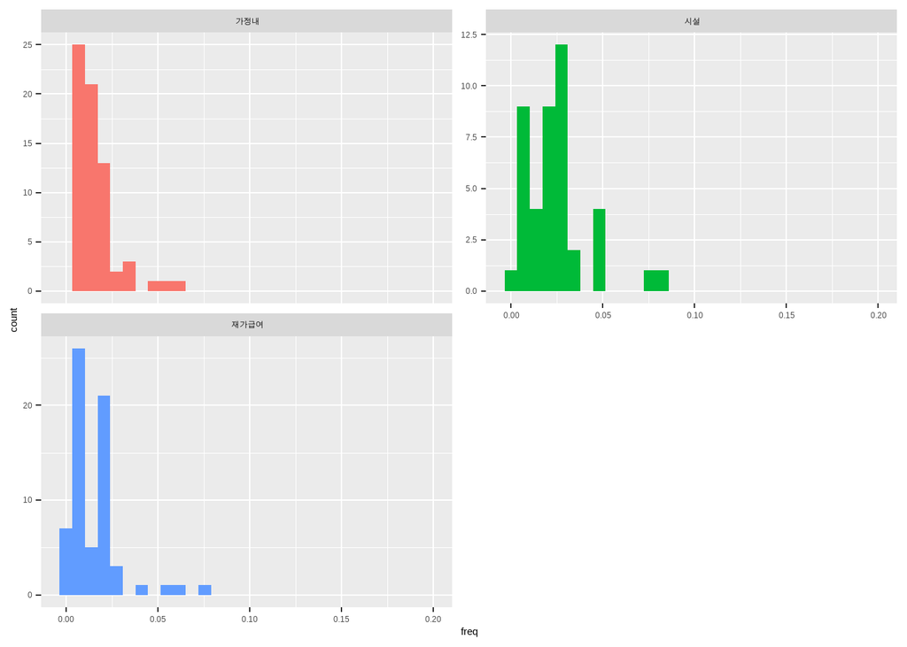

```r
library(ggplot2)

ggplot(frequency, aes(freq, fill = institute)) +
  geom_histogram(show.legend = FALSE) +
  xlim(NA, 0.20) +
  facet_wrap(~institute, ncol = 2, scales = "free_y")
```

```r
frequency1_tf_idf <- frequency %>%
  bind_tf_idf(nouns, institute, count)

frequency1_tf_idf
```

| institute | nouns | count | total | freq | tf | idf | tf_idf |
| --- | --- | --- | --- | --- | --- | --- | --- |
| 가정내 | 생활 | 70 | 1118 | 0.062611807 | 0.062611807 | 0.0000000 | 0.0000000000 |
| 가정내 | 엄마 | 58 | 1118 | 0.051878354 | 0.051878354 | 0.0000000 | 0.0000000000 |
| 가정내 | 제약 | 53 | 1118 | 0.047406082 | 0.047406082 | 0.4054651 | 0.0192215123 |
| 가정내 | 개인 | 42 | 1118 | 0.037567084 | 0.037567084 | 0.4054651 | 0.0152321418 |
| 가정내 | 단절 | 42 | 1118 | 0.037567084 | 0.037567084 | 1.0986123 | 0.0412716602 |
| 가정내 | 활동 | 39 | 1118 | 0.034883721 | 0.034883721 | 1.0986123 | 0.0383236845 |
| 가정내 | 모임 | 31 | 1118 | 0.027728086 | 0.027728086 | 0.4054651 | 0.0112427713 |
| 가정내 | 집 | 28 | 1118 | 0.025044723 | 0.025044723 | 0.4054651 | 0.0101547612 |
| 가정내 | 상황 | 26 | 1118 | 0.023255814 | 0.023255814 | 0.0000000 | 0.0000000000 |
| 가정내 | 퇴근 | 25 | 1118 | 0.022361360 | 0.022361360 | 1.0986123 | 0.0245664644 |

[output cut: 166 more lines]

```r
frequency1_tf_idf <-frequency1_tf_idf %>%
  select(-total) %>%
  arrange(institute, desc(tf_idf))

write_xlsx(frequency1_tf_idf, "freq_tf_idf_soc_by_institute.xlsx")
```

- freq_tf_idf_soc_by_institute.xlsx ==> 시설별 사회적 부담 상위 td-idf 연관어

## 4.4. 시설별 TF-IDF 행렬 만들기

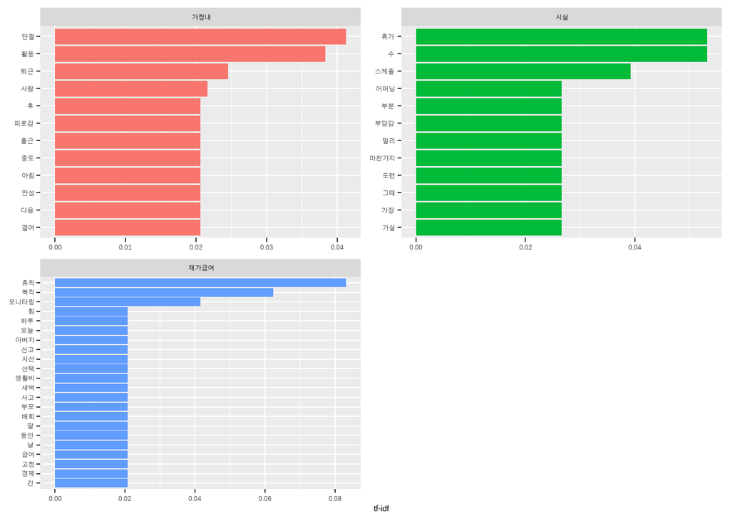

```r
library(forcats)

frequency1_tf_idf %>%
  group_by(institute) %>%
  slice_max(tf_idf, n = 7) %>%
  ungroup() %>%
  ggplot(aes(tf_idf, fct_reorder(nouns, tf_idf), fill = institute)) +
  geom_col(show.legend = FALSE) +
  facet_wrap(~institute, ncol = 2, scales = "free") +
  labs(x = "tf-idf", y = NULL)
```

```r
library(tidyr)
table(frequency$institute)
```

```
##
##   가정내     시설 재가급여
##       67       43       66
```

```r
frequency <- frequency %>%
  select(institute, nouns, freq) %>%
  pivot_wider(names_from = institute, values_from = freq)

frequency
```

| nouns | 가정내 | 시설 | 재가급여 |
| --- | --- | --- | --- |
| 생활 | 0.062611807 | 0.030612245 | 0.008284024 |
| 엄마 | 0.051878354 | 0.005102041 | 0.007692308 |
| 제약 | 0.047406082 | NA | 0.020118343 |
| 개인 | 0.037567084 | NA | 0.026627219 |
| 단절 | 0.037567084 | NA | NA |
| 활동 | 0.034883721 | NA | NA |
| 모임 | 0.027728086 | NA | 0.028402367 |
| 집 | 0.025044723 | NA | 0.016568047 |
| 상황 | 0.023255814 | 0.085459184 | 0.008284024 |
| 퇴근 | 0.022361360 | NA | NA |

[output cut: 131 more lines]

## 4.5. 시설별 단어빈도 비교

### 4.5.1. 시설 대 가정내

```r
word_ratios <- collapsed_dfsoc2 %>%
  filter(count >= 10) %>%
  pivot_wider(names_from = institute, values_from = count, values_fill = 0) %>%
  mutate_if(is.numeric, list(~(. + 1) / (sum(.) + 1))) %>%
  mutate(logratio = log(시설/가정내)) %>%
  arrange(desc(logratio))
word_ratios %>%
  arrange(abs(logratio))
```

| nouns | 가정내 | 시설 | 재가급여 | logratio |
| --- | --- | --- | --- | --- |
| 간 | 0.0009699321 | 0.001351351 | 0.0206121174 | 0.3316343 |
| 경제 | 0.0009699321 | 0.001351351 | 0.0206121174 | 0.3316343 |
| 고정 | 0.0009699321 | 0.001351351 | 0.0206121174 | 0.3316343 |
| 급여 | 0.0009699321 | 0.001351351 | 0.0206121174 | 0.3316343 |
| 날 | 0.0009699321 | 0.001351351 | 0.0206121174 | 0.3316343 |
| 동안 | 0.0009699321 | 0.001351351 | 0.0206121174 | 0.3316343 |
| 등한시 | 0.0009699321 | 0.001351351 | 0.0087445347 | 0.3316343 |
| 말 | 0.0009699321 | 0.001351351 | 0.0206121174 | 0.3316343 |
| 며느리 | 0.0009699321 | 0.001351351 | 0.0093691443 | 0.3316343 |
| 모니터링 | 0.0009699321 | 0.001351351 | 0.0405996252 | 0.3316343 |

[output cut: 101 more lines]

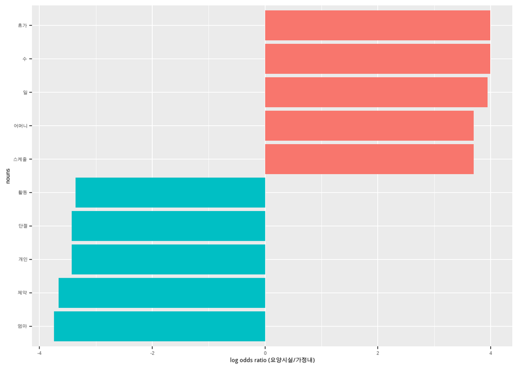

```r
word_ratios %>%
  group_by(logratio < 0) %>%
  slice_max(abs(logratio), n = 5) %>%
  ungroup() %>%
  mutate(nouns = reorder(nouns, logratio)) %>%
  ggplot(aes(nouns, logratio, fill = logratio < 0)) +
  geom_col(show.legend = FALSE) +
  coord_flip() +
  ylab("log odds ratio (요양시설/가정내)") +
  scale_fill_discrete(name = "", labels = c("요양시설", "가정내"))
```

### 4.5.2. 시설 대 재가급여

```r
word_ratios2 <- collapsed_dfsoc2 %>%
  filter(count >= 10) %>%
  pivot_wider(names_from = institute, values_from = count, values_fill = 0) %>%
  mutate_if(is.numeric, list(~(. + 1) / (sum(.) + 1))) %>%
  mutate(logratio = log(시설/재가급여)) %>%
  arrange(desc(logratio))
word_ratios2 %>%
  arrange(abs(logratio))
```

| nouns | 가정내 | 시설 | 재가급여 | logratio |
| --- | --- | --- | --- | --- |
| 약속 | 0.0116391853 | 0.017567568 | 0.0168644597 | 0.04084602 |
| 때 | 0.0126091174 | 0.050000000 | 0.0287320425 | 0.55401004 |
| 가능 | 0.0155189137 | 0.001351351 | 0.0006246096 | 0.77173353 |
| 결여 | 0.0213385063 | 0.001351351 | 0.0006246096 | 0.77173353 |
| 다음 | 0.0213385063 | 0.001351351 | 0.0006246096 | 0.77173353 |
| 단절 | 0.0417070805 | 0.001351351 | 0.0006246096 | 0.77173353 |
| 뒤 | 0.0126091174 | 0.001351351 | 0.0006246096 | 0.77173353 |
| 만성 | 0.0213385063 | 0.001351351 | 0.0006246096 | 0.77173353 |
| 말씀 | 0.0155189137 | 0.001351351 | 0.0006246096 | 0.77173353 |
| 본의 | 0.0116391853 | 0.001351351 | 0.0006246096 | 0.77173353 |

[output cut: 101 more lines]

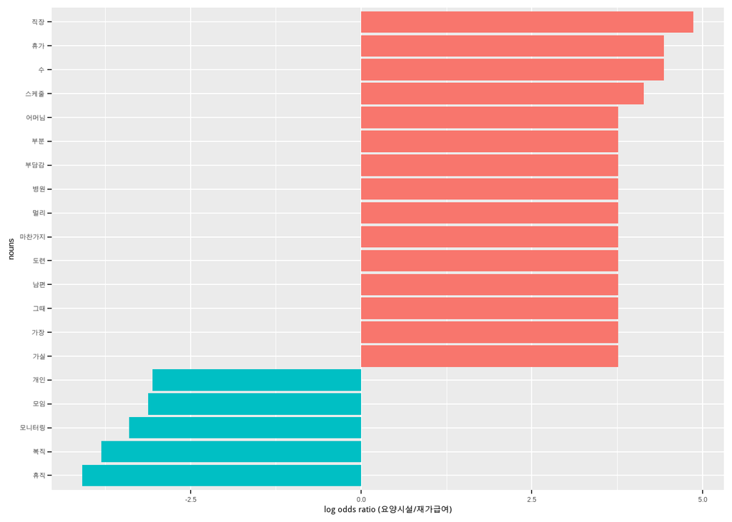

```r
word_ratios2 %>%
  group_by(logratio < 0) %>%
  slice_max(abs(logratio), n = 5) %>%
  ungroup() %>%
  mutate(nouns = reorder(nouns, logratio)) %>%
  ggplot(aes(nouns, logratio, fill = logratio < 0)) +
  geom_col(show.legend = FALSE) +
  coord_flip() +
  ylab("log odds ratio (요양시설/재가급여)") +
  scale_fill_discrete(name = "", labels = c("요양시설", "재가급여"))
```

```r
word_ratios3 <- collapsed_dfsoc2 %>%
  filter(count >= 10) %>%
  pivot_wider(names_from = institute, values_from = count, values_fill = 0) %>%
  mutate_if(is.numeric, list(~(. + 1) / (sum(.) + 1))) %>%
  mutate(logratio = log(재가급여/시설)) %>%
  arrange(desc(logratio))
word_ratios3 %>%
  arrange(abs(logratio))
```

| nouns | 가정내 | 시설 | 재가급여 | logratio |
| --- | --- | --- | --- | --- |
| 약속 | 0.0116391853 | 0.017567568 | 0.0168644597 | -0.04084602 |
| 때 | 0.0126091174 | 0.050000000 | 0.0287320425 | -0.55401004 |
| 가능 | 0.0155189137 | 0.001351351 | 0.0006246096 | -0.77173353 |
| 결여 | 0.0213385063 | 0.001351351 | 0.0006246096 | -0.77173353 |
| 다음 | 0.0213385063 | 0.001351351 | 0.0006246096 | -0.77173353 |
| 단절 | 0.0417070805 | 0.001351351 | 0.0006246096 | -0.77173353 |
| 뒤 | 0.0126091174 | 0.001351351 | 0.0006246096 | -0.77173353 |
| 만성 | 0.0213385063 | 0.001351351 | 0.0006246096 | -0.77173353 |
| 말씀 | 0.0155189137 | 0.001351351 | 0.0006246096 | -0.77173353 |
| 본의 | 0.0116391853 | 0.001351351 | 0.0006246096 | -0.77173353 |

[output cut: 101 more lines]

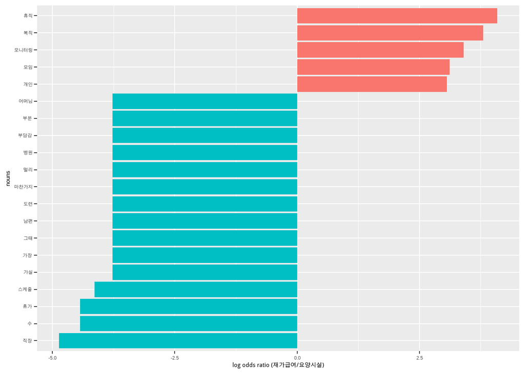

```r
word_ratios3 %>%
  group_by(logratio < 0) %>%
  slice_max(abs(logratio), n = 5) %>%
  ungroup() %>%
  mutate(nouns = reorder(nouns, logratio)) %>%
  ggplot(aes(nouns, logratio, fill = logratio < 0)) +
  geom_col(show.legend = FALSE) +
  coord_flip() +
  ylab("log odds ratio (재가급여/요양시설)") +
  scale_fill_discrete(name = "", labels = c("재가급여", "요양시설"))
```

## 4.6. 사회적 부담 토픽모델링

### 4.6.1. 토픽모델링을 위한 데이터 변환

```r
## DTM 변환
dfsoc_dtm <- dfsoc_bow %>%
  cast_dtm(document = no, term = nouns, value = n) %>%
  as.matrix
## LDA 모형 적합
dfsoc_lda <- LDA(dfsoc_dtm, k = 3,  method="Gibbs",
                  control=list(alpha=0.1, delta=0.1, seed=1357))
dfsoc_topics <- tidy(dfsoc_lda, matrix = "beta")
dfsoc_topics
```

| topic | term | beta |
| --- | --- | --- |
| 1 | 휴직 | 0.0009514748 |
| 2 | 휴직 | 0.0499390987 |
| 3 | 휴직 | 0.0009514748 |
| 1 | 일 | 0.0009514748 |
| 2 | 일 | 0.0621193666 |
| 3 | 일 | 0.0009514748 |
| 1 | 복직 | 0.0009514748 |
| 2 | 복직 | 0.0377588307 |
| 3 | 복직 | 0.0009514748 |
| 1 | 엄마 | 0.0009514748 |

[output cut: 413 more lines]

### 4.6.2. 세 개 주요토픽 추출

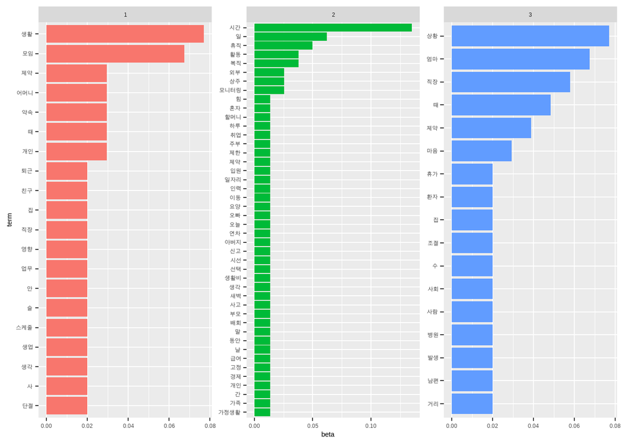

```r
dfsoc_top_terms <- dfsoc_topics %>%
  group_by(topic) %>%
  slice_max(beta, n = 10) %>%
  ungroup() %>%
  arrange(topic, -beta)

dfsoc_top_terms %>%
  mutate(term = reorder_within(term, beta, topic)) %>%
  ggplot(aes(beta, term, fill = factor(topic))) +
  geom_col(show.legend = FALSE) +
  facet_wrap(~ topic, scales = "free") +
  scale_y_reordered()
```

### 4.6.3. 토픽결과 행렬

```r
## 토픽 결과 - 행렬
tidy(dfsoc_lda, matrix="gamma") %>%
  arrange(document) %>%
  spread(topic, gamma)
```

| document | 1 | 2 | 3 |
| --- | --- | --- | --- |
| 1 | 0.962264151 | 0.018867925 | 0.018867925 |
| 10 | 0.566433566 | 0.076923077 | 0.356643357 |
| 12 | 0.396226415 | 0.584905660 | 0.018867925 |
| 13 | 0.333333333 | 0.030303030 | 0.636363636 |
| 14 | 0.233082707 | 0.233082707 | 0.533834586 |
| 15 | 0.003095975 | 0.993808050 | 0.003095975 |
| 16 | 0.763440860 | 0.118279570 | 0.118279570 |
| 17 | 0.846153846 | 0.076923077 | 0.076923077 |
| 18 | 0.023255814 | 0.720930233 | 0.255813953 |
| 19 | 0.539823009 | 0.008849558 | 0.451327434 |

[output cut: 17 more lines]

### 4.6.4. 단어별 토픽 log-ratio

```r
library(tidyr)

beta_wide <- dfsoc_topics %>%
  mutate(topic = paste0("topic", topic)) %>%
  pivot_wider(names_from = topic, values_from = beta) %>%
  filter(topic1 > .001 | topic2 > .001) %>%
  mutate(log_ratio = log2(topic2 / topic1))

beta_wide
```

| term | topic1 | topic2 | topic3 | log_ratio |
| --- | --- | --- | --- | --- |
| 휴직 | 0.0009514748 | 0.049939099 | 0.0009514748 | 5.7138605 |
| 일 | 0.0009514748 | 0.062119367 | 0.0009514748 | 6.0287339 |
| 복직 | 0.0009514748 | 0.037758831 | 0.0009514748 | 5.3105049 |
| 엄마 | 0.0009514748 | 0.001218027 | 0.0675547098 | 0.3563085 |
| 상황 | 0.0009514748 | 0.001218027 | 0.0770694577 | 0.3563085 |
| 거리 | 0.0009514748 | 0.001218027 | 0.0199809705 | 0.3563085 |
| 수 | 0.0009514748 | 0.001218027 | 0.0199809705 | 0.3563085 |
| 휴가 | 0.0009514748 | 0.001218027 | 0.0199809705 | 0.3563085 |
| 스케줄 | 0.0199809705 | 0.001218027 | 0.0009514748 | -4.0360089 |
| 어머니 | 0.0294957184 | 0.001218027 | 0.0009514748 | -4.5978878 |

[output cut: 131 more lines]

## 4.7. 사회적 부담 토픽 결과 - 시각화

### 4.7.1. 시설별 토픽 분류

```r
dfsoc_gamma <- tidy(dfsoc_lda, matrix="gamma")
dfsoc_gamma$no=as.numeric(dfsoc_gamma$document)
dfsoc_gamma <- left_join(dfsoc_gamma, dfsoc_tk)
```

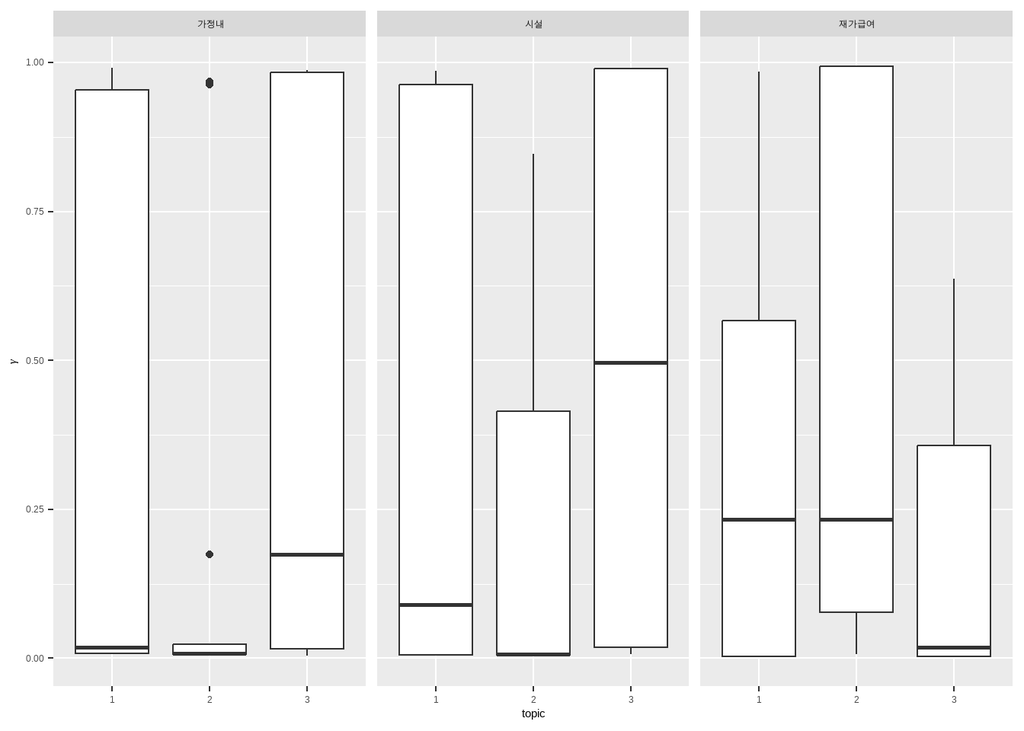

```r
dfsoc_gamma %>%
  ggplot(aes(factor(topic), gamma)) +
  geom_boxplot() +
  facet_wrap(~ institute) +
  labs(x = "topic", y = expression(gamma))
```

### 4.7.2. 주관적 사회적 부담 수준별 (상중하) 토픽 분류

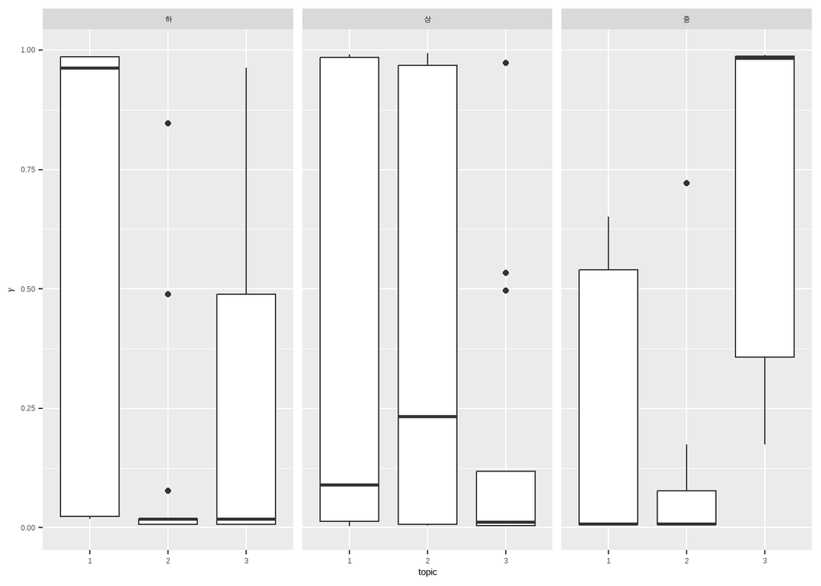

```r
dfsoc_gamma$social= as.factor(dfsoc_gamma$social)
dfsoc_gamma %>%
  mutate(social = reorder(social, gamma * topic)) %>%
  ggplot(aes(factor(topic), gamma)) +
  geom_boxplot() +
  facet_wrap(~ social) +
  labs(x = "topic", y = expression(gamma))
```

### 4.7.3. 세개의 토픽에 주로 연결되는 보호자

```r
tidy(dfsoc_lda, matrix="gamma") %>%
  filter((topic==1 & gamma > .9) | (topic==2 & gamma > .9) |(topic==3 & gamma > .8))
```

| document | topic | gamma |
| --- | --- | --- |
| 7 | 1 | 0.9860140 |
| 9 | 1 | 0.9849624 |
| 22 | 1 | 0.9906103 |
| 1 | 1 | 0.9622642 |
| 23 | 1 | 0.9534884 |
| 15 | 2 | 0.9938080 |
| 26 | 2 | 0.9622642 |
| 27 | 2 | 0.9682540 |
| 25 | 2 | 0.9622642 |
| 21 | 3 | 0.9869281 |

[output cut: 4 more lines]

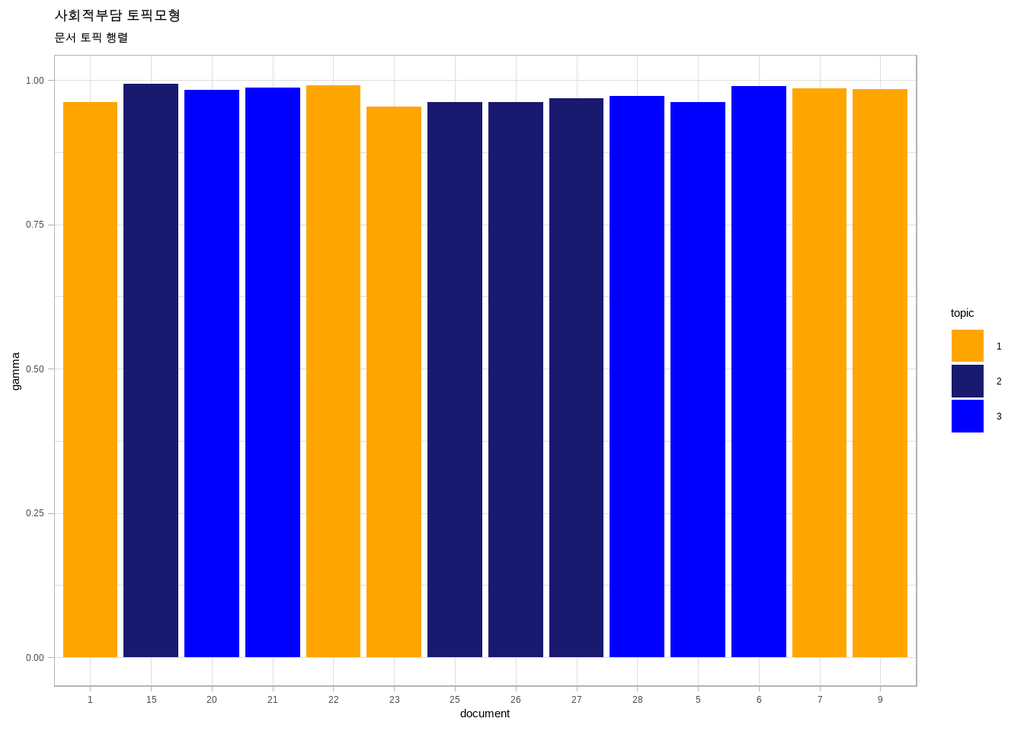

```r
dfsoc_topic_g <- tidy(dfsoc_lda, matrix="gamma") %>%
  filter((topic==1 & gamma > .9) | (topic==2 & gamma > .9) |(topic==3 & gamma > .8)) %>%
  mutate(topic = as.factor(topic)) %>%
  ggplot(aes(x = document, y=gamma)) +
    geom_col(aes(fill = topic), position=position_dodge()) +
    scale_fill_manual(values = c("orange", "midnightblue", "blue")) +
    theme_light() +
    labs(title="사회적부담 토픽모형",
         subtitle = "문서 토픽 행렬")
dfsoc_topic_g
```

# 5. 의존적 부담 토픽분석

## 5.1. 의존적 부담 텍스트 전처리

```r
rm(list=ls())
df <- readxl::read_excel("df5.xlsx")
df<-unite(df, col='dep1', c('dep1', 'dep2'), sep='. ')
sf_dep<-df%>%
  select(no, dep1, institute, dependet)
```

```r
dfdep_tk <- sf_dep %>%
  # 문자 혹은 공백 이외 것 제거
  mutate(text = str_remove_all(dep1, "[^(\\w+|\\s)]")) %>%
  # 메카브로 품사 중 명사만 추출
  unnest_tokens(word, text, token = RcppMeCab::pos, drop = FALSE) %>%
  separate(col = word,
         into = c("word", "morph"),
         sep = "/" ) %>%
  filter(morph == "nng")

dfdep_tk %>% glimpse()
```

```
## Rows: 234
## Columns: 7
## $ no        <dbl> 1, 1, 1, 1, 2, 2, 2, 2, 2, 2, 3, 3, 3, 3, 3, 3, 4, 4, 4, 4, …
## $ dep1      <chr> "인지가 있을 때는 자주 찾아와서 가족의 안부를 듣고 싶어 하셨…
## $ institute <chr> "시설", "시설", "시설", "시설", "시설", "시설", "시설", "시…
## $ dependet  <chr> "중", "중", "중", "중", "하", "하", "하", "하", "하", "하", …
## $ text      <chr> "인지가 있을 때는 자주 찾아와서 가족의 안부를 듣고 싶어 하셨…
## $ word      <chr> "인지", "때", "가족", "안부", "병원", "때", "병원", "그때", …
## $ morph     <chr> "nng", "nng", "nng", "nng", "nng", "nng", "nng", "nng", "nng…
```

```r
dfdep_tk$no <- as.numeric(dfdep_tk$no)
```

## 5.2. 데이터 변환

```r
## BOW 데이터 변환
dfdep_bow <- sf_dep %>%
  ## 문서 내 텍스트에서 명사 추출
  mutate(mecab_pos = map(dep1, RcppMeCab::pos) ) %>%
  unnest(mecab_pos) %>%
  unnest(mecab_pos) %>%
  separate(mecab_pos, into = c("nouns", "pos"), sep = "/") %>%
  filter(pos == "NNG") %>%
  ## 문서별 명사 빈도수
  group_by(no) %>%
  count(nouns, sort = TRUE)
dfdep_bow$no <- as.numeric(dfdep_bow$no)

dfdep2 <- inner_join(dfdep_bow, dfdep_tk)
collapsed_dfdep2 <- dfdep2 %>%
  group_by(nouns) %>%
  summarize(count = sum(n, na.rm = TRUE))


collapsed_dfdep2$total <- sum(collapsed_dfdep2$count)
collapsed_dfdep2$freq <- collapsed_dfdep2$count/collapsed_dfdep2$total
freq_dep_all<-collapsed_dfdep2  %>%
  filter(count>29)

freq_dep_all <- freq_dep_all[order(-freq_dep_all$count), ]

write_xlsx(freq_dep_all, "freq_dep_all.xlsx")


collapsed_dfdep2 <- dfdep2 %>%
  group_by(institute, nouns) %>%
  summarize(count = sum(n, na.rm = TRUE))
```

- freq_dep_all.xlsx ==> <의존적적 부담의 상위 연관어>

```r
png("dep_plot.png")
dep_plot<- ggplot(data = freq_dep_all, aes(label = nouns, size = count, color = count))+
  geom_text_wordcloud_area(area_corr_power = 1, eccentricity = 1)+
  scale_size_area(max_size = 20) +
  scale_color_gradient(low = "#C7DDEC", high = "#1F78B4") +
  theme_minimal()
print(dep_plot)
dev.off()
```

- dep_plot.png ==> 의존적 부담 전체 워드 클라우드 (박종도 2019, 285) 워드클라우드 그림 참조

## 5.3. 시설별 단어 빈도분석

```r
frequency <- collapsed_dfdep2 %>%
  left_join(collapsed_dfdep2 %>% group_by(institute)%>%
              summarize(total=sum(count, na.rm=TRUE))) %>%
  mutate(freq = count/total)
frequency<- frequency[order(frequency$institute, -frequency$freq), ]
frequency
```

| institute | nouns | count | total | freq |
| --- | --- | --- | --- | --- |
| 가정내 | 엄마 | 114 | 913 | 0.1248630887 |
| 가정내 | 전화 | 72 | 913 | 0.0788608981 |
| 가정내 | 때 | 67 | 913 | 0.0733844469 |
| 가정내 | 얘기 | 60 | 913 | 0.0657174151 |
| 가정내 | 일상 | 50 | 913 | 0.0547645126 |
| 가정내 | 요구 | 45 | 913 | 0.0492880613 |
| 가정내 | 생활 | 30 | 913 | 0.0328587076 |
| 가정내 | 본인 | 26 | 913 | 0.0284775465 |
| 가정내 | 아버님 | 26 | 913 | 0.0284775465 |
| 가정내 | 시간 | 20 | 913 | 0.0219058050 |

[output cut: 140 more lines]

```r
write_xlsx(freq_dep_all, "freq_dep_by_institute.xlsx")
```

```r
summary(frequency)
```

```
##   institute            nouns               count            total
##  Length:150         Length:150         Min.   :  1.00   Min.   : 266
##  Class :character   Class :character   1st Qu.:  6.00   1st Qu.: 913
##  Mode  :character   Mode  :character   Median : 12.00   Median : 913
##                                        Mean   : 19.69   Mean   :1142
##                                        3rd Qu.: 24.00   3rd Qu.:1774
##                                        Max.   :114.00   Max.   :1774
##       freq
##  Min.   :0.0005637
##  1st Qu.:0.0076670
##  Median :0.0142388
##  Mean   :0.0200000
##  3rd Qu.:0.0225564
##  Max.   :0.1248631
```

```r
summary(frequency$count)
```

```
##    Min. 1st Qu.  Median    Mean 3rd Qu.    Max.
##    1.00    6.00   12.00   19.69   24.00  114.00
```

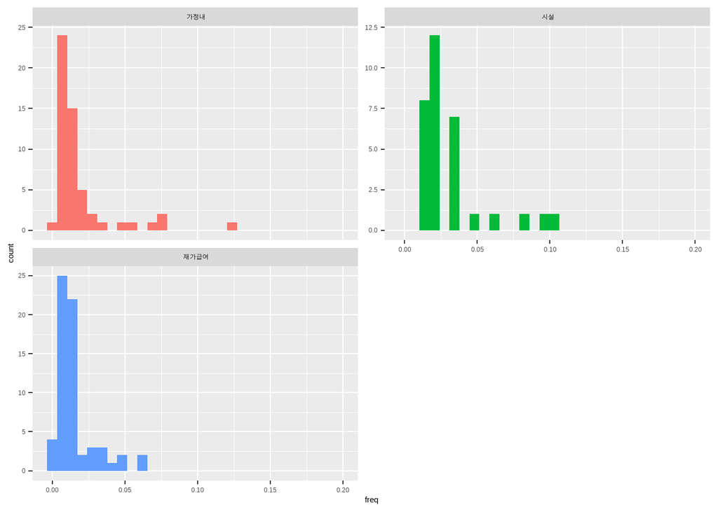

```r
library(ggplot2)

ggplot(frequency, aes(freq, fill = institute)) +
  geom_histogram(show.legend = FALSE) +
  xlim(NA, 0.20) +
  facet_wrap(~institute, ncol = 2, scales = "free_y")
```

```r
frequency1_tf_idf <- frequency %>%
  bind_tf_idf(nouns, institute, count)

frequency1_tf_idf
```

| institute | nouns | count | total | freq | tf | idf | tf_idf |
| --- | --- | --- | --- | --- | --- | --- | --- |
| 가정내 | 엄마 | 114 | 913 | 0.1248630887 | 0.1248630887 | 0.0000000 | 0.0000000000 |
| 가정내 | 전화 | 72 | 913 | 0.0788608981 | 0.0788608981 | 0.4054651 | 0.0319753426 |
| 가정내 | 때 | 67 | 913 | 0.0733844469 | 0.0733844469 | 0.0000000 | 0.0000000000 |
| 가정내 | 얘기 | 60 | 913 | 0.0657174151 | 0.0657174151 | 1.0986123 | 0.0721979598 |
| 가정내 | 일상 | 50 | 913 | 0.0547645126 | 0.0547645126 | 1.0986123 | 0.0601649665 |
| 가정내 | 요구 | 45 | 913 | 0.0492880613 | 0.0492880613 | 0.4054651 | 0.0199845891 |
| 가정내 | 생활 | 30 | 913 | 0.0328587076 | 0.0328587076 | 1.0986123 | 0.0360989799 |
| 가정내 | 본인 | 26 | 913 | 0.0284775465 | 0.0284775465 | 0.4054651 | 0.0115466515 |
| 가정내 | 아버님 | 26 | 913 | 0.0284775465 | 0.0284775465 | 1.0986123 | 0.0312857826 |
| 가정내 | 시간 | 20 | 913 | 0.0219058050 | 0.0219058050 | 0.4054651 | 0.0088820396 |

[output cut: 140 more lines]

```r
frequency1_tf_idf <-frequency1_tf_idf %>%
  select(-total) %>%
  arrange(institute, desc(tf_idf))

write_xlsx(frequency1_tf_idf, "freq_tf_idf_dep_by_institute.xlsx")
```

- freq_tf_idf_dep_by_institute.xlsx ==> 시설별 의존적 부담 상위 td-idf 연관어

## 5.4. 시설별 TF-IDF 행렬 만들기

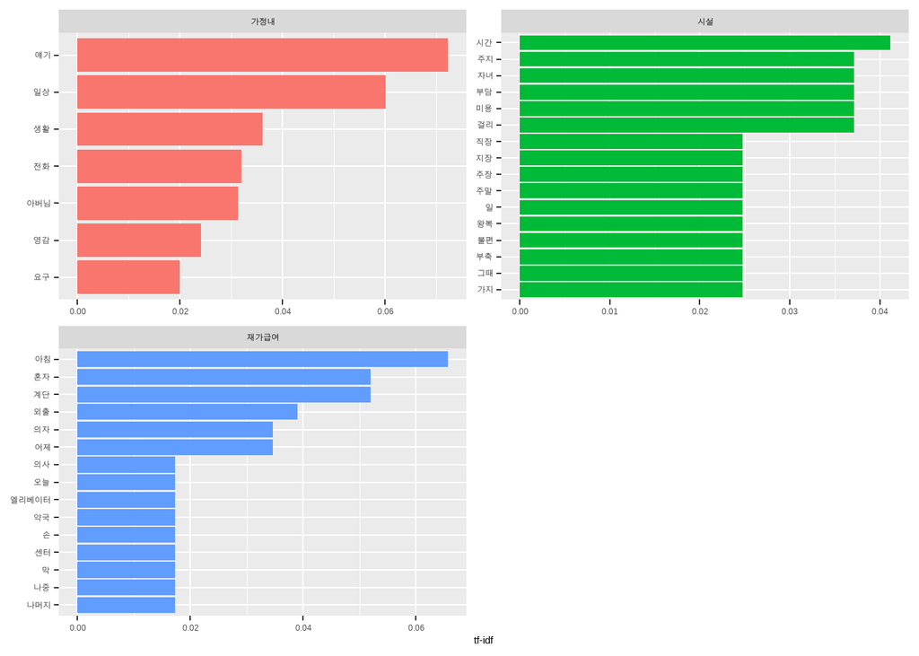

```r
library(forcats)

frequency1_tf_idf %>%
  group_by(institute) %>%
  slice_max(tf_idf, n = 7) %>%
  ungroup() %>%
  ggplot(aes(tf_idf, fct_reorder(nouns, tf_idf), fill = institute)) +
  geom_col(show.legend = FALSE) +
  facet_wrap(~institute, ncol = 2, scales = "free") +
  labs(x = "tf-idf", y = NULL)
```

```r
library(tidyr)
table(frequency$institute)
```

```
##
##   가정내     시설 재가급여
##       54       32       64
```

```r
frequency <- frequency %>%
  select(institute, nouns, freq) %>%
  pivot_wider(names_from = institute, values_from = freq)

frequency
```

| nouns | 가정내 | 시설 | 재가급여 |
| --- | --- | --- | --- |
| 엄마 | 0.124863089 | 0.01127820 | 0.0157835400 |
| 전화 | 0.078860898 | NA | 0.0191657272 |
| 때 | 0.073384447 | 0.08270677 | 0.0586245772 |
| 얘기 | 0.065717415 | NA | NA |
| 일상 | 0.054764513 | NA | NA |
| 요구 | 0.049288061 | NA | 0.0095828636 |
| 생활 | 0.032858708 | NA | NA |
| 본인 | 0.028477547 | NA | 0.0191657272 |
| 아버님 | 0.028477547 | NA | NA |
| 시간 | 0.021905805 | 0.10150376 | NA |

[output cut: 114 more lines]

## 5.5. 시설별 단어빈도 비교

### 5.5.1. 시설 대 가정내

```r
word_ratios <- collapsed_dfdep2 %>%
  filter(count >= 10) %>%
  pivot_wider(names_from = institute, values_from = count, values_fill = 0) %>%
  mutate_if(is.numeric, list(~(. + 1) / (sum(.) + 1))) %>%
  mutate(logratio = log(시설/가정내)) %>%
  arrange(desc(logratio))
word_ratios %>%
  arrange(abs(logratio))
```

| nouns | 가정내 | 시설 | 재가급여 | logratio |
| --- | --- | --- | --- | --- |
| 가스 | 0.014416776 | 0.009708738 | 0.000575374 | -0.3953662 |
| 경우 | 0.014416776 | 0.009708738 | 0.000575374 | -0.3953662 |
| 불 | 0.014416776 | 0.009708738 | 0.000575374 | -0.3953662 |
| 서서 | 0.014416776 | 0.009708738 | 0.000575374 | -0.3953662 |
| 싱크대 | 0.014416776 | 0.009708738 | 0.000575374 | -0.3953662 |
| 일체 | 0.014416776 | 0.009708738 | 0.000575374 | -0.3953662 |
| 잠 | 0.017038008 | 0.009708738 | 0.000575374 | -0.5624203 |
| 가달 | 0.018348624 | 0.009708738 | 0.000575374 | -0.6365283 |
| 거부 | 0.018348624 | 0.009708738 | 0.000575374 | -0.6365283 |
| 경향 | 0.018348624 | 0.009708738 | 0.000575374 | -0.6365283 |

[output cut: 70 more lines]

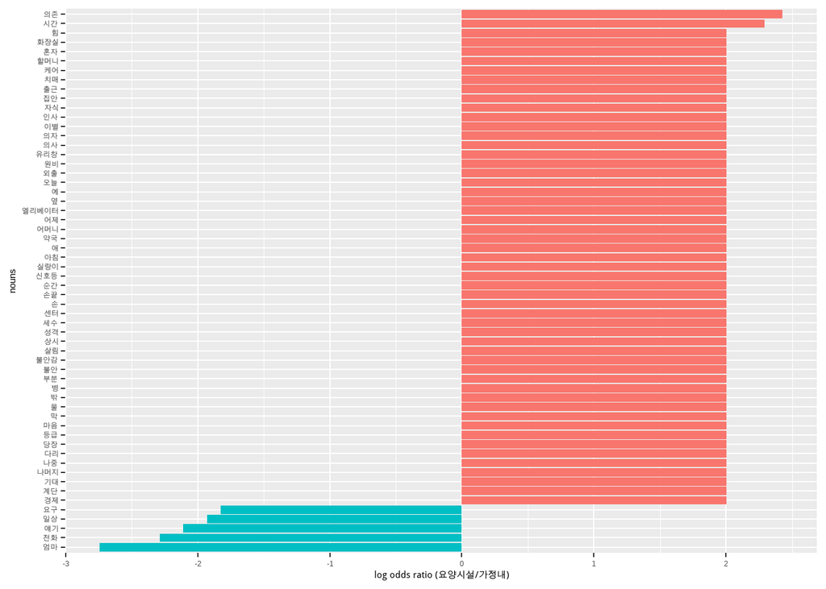

```r
word_ratios %>%
  group_by(logratio < 0) %>%
  slice_max(abs(logratio), n = 5) %>%
  ungroup() %>%
  mutate(nouns = reorder(nouns, logratio)) %>%
  ggplot(aes(nouns, logratio, fill = logratio < 0)) +
  geom_col(show.legend = FALSE) +
  coord_flip() +
  ylab("log odds ratio (요양시설/가정내)") +
  scale_fill_discrete(name = "", labels = c("요양시설", "가정내"))
```

### 5.5.2. 시설 대 재가급여

```r
word_ratios2 <- collapsed_dfdep2 %>%
  filter(count >= 10) %>%
  pivot_wider(names_from = institute, values_from = count, values_fill = 0) %>%
  mutate_if(is.numeric, list(~(. + 1) / (sum(.) + 1))) %>%
  mutate(logratio = log(시설/재가급여)) %>%
  arrange(desc(logratio))
word_ratios2 %>%
  arrange(abs(logratio))
```

| nouns | 가정내 | 시설 | 재가급여 | logratio |
| --- | --- | --- | --- | --- |
| 요구 | 0.060288336 | 0.009708738 | 0.010356732 | -0.06461044 |
| 밖 | 0.001310616 | 0.009708738 | 0.010356732 | -0.06461044 |
| 불안 | 0.001310616 | 0.009708738 | 0.010356732 | -0.06461044 |
| 불안감 | 0.001310616 | 0.009708738 | 0.010356732 | -0.06461044 |
| 상시 | 0.001310616 | 0.009708738 | 0.010356732 | -0.06461044 |
| 신호등 | 0.001310616 | 0.009708738 | 0.010356732 | -0.06461044 |
| 옆 | 0.001310616 | 0.009708738 | 0.010356732 | -0.06461044 |
| 예 | 0.001310616 | 0.009708738 | 0.010356732 | -0.06461044 |
| 케어 | 0.001310616 | 0.009708738 | 0.010356732 | -0.06461044 |
| 유리창 | 0.001310616 | 0.009708738 | 0.010932106 | -0.11867766 |

[output cut: 70 more lines]

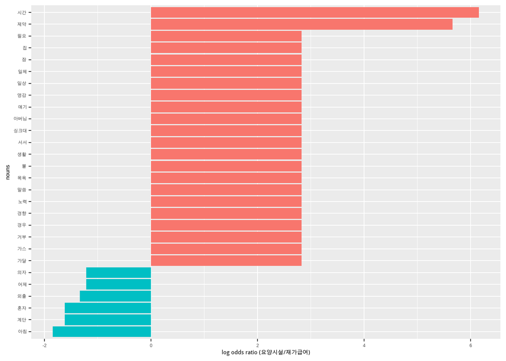

```r
word_ratios2 %>%
  group_by(logratio < 0) %>%
  slice_max(abs(logratio), n = 5) %>%
  ungroup() %>%
  mutate(nouns = reorder(nouns, logratio)) %>%
  ggplot(aes(nouns, logratio, fill = logratio < 0)) +
  geom_col(show.legend = FALSE) +
  coord_flip() +
  ylab("log odds ratio (요양시설/재가급여)") +
  scale_fill_discrete(name = "", labels = c("요양시설", "재가급여"))
```

```r
word_ratios3 <- collapsed_dfdep2 %>%
  filter(count >= 10) %>%
  pivot_wider(names_from = institute, values_from = count, values_fill = 0) %>%
  mutate_if(is.numeric, list(~(. + 1) / (sum(.) + 1))) %>%
  mutate(logratio = log(재가급여/시설)) %>%
  arrange(desc(logratio))
word_ratios3 %>%
  arrange(abs(logratio))
```

| nouns | 가정내 | 시설 | 재가급여 | logratio |
| --- | --- | --- | --- | --- |
| 요구 | 0.060288336 | 0.009708738 | 0.010356732 | 0.06461044 |
| 밖 | 0.001310616 | 0.009708738 | 0.010356732 | 0.06461044 |
| 불안 | 0.001310616 | 0.009708738 | 0.010356732 | 0.06461044 |
| 불안감 | 0.001310616 | 0.009708738 | 0.010356732 | 0.06461044 |
| 상시 | 0.001310616 | 0.009708738 | 0.010356732 | 0.06461044 |
| 신호등 | 0.001310616 | 0.009708738 | 0.010356732 | 0.06461044 |
| 옆 | 0.001310616 | 0.009708738 | 0.010356732 | 0.06461044 |
| 예 | 0.001310616 | 0.009708738 | 0.010356732 | 0.06461044 |
| 케어 | 0.001310616 | 0.009708738 | 0.010356732 | 0.06461044 |
| 유리창 | 0.001310616 | 0.009708738 | 0.010932106 | 0.11867766 |

[output cut: 70 more lines]

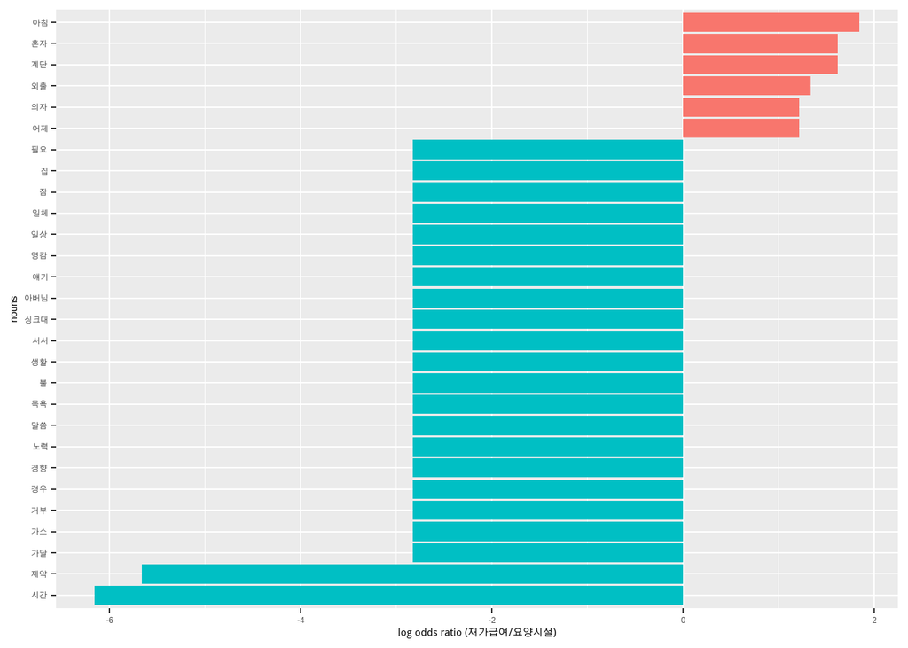

```r
word_ratios3 %>%
  group_by(logratio < 0) %>%
  slice_max(abs(logratio), n = 5) %>%
  ungroup() %>%
  mutate(nouns = reorder(nouns, logratio)) %>%
  ggplot(aes(nouns, logratio, fill = logratio < 0)) +
  geom_col(show.legend = FALSE) +
  coord_flip() +
  ylab("log odds ratio (재가급여/요양시설)") +
  scale_fill_discrete(name = "", labels = c("재가급여", "요양시설"))
```